# Exploring the factors impacting sleep quality among Chinese undergraduates in Jiangsu Province: Multiple models’ analyses

xiao

2023-05-22

### Introduction

This document contains the source codes and corresponding execution results of the submitted paper “Prevalence and related factors of sleep quality among Chinese undergraduates in Jiangsu Province: Multiple models’ analysis”, including all detailed codes for tables, figures, and the adopted models (multiple linear regression, binary logistic regression, linear mixed model, logistic random effect regression) with diagnostics.

### Load necessary package

```r
rm(list = ls())
pkg <- c('car','pROC','ltm','tidyverse','rstatix','bruceR','cowplot','lmerTest','sjPlot','sjmisc','sjlabelled')
lapply(pkg,function(x){library(x,character.only = T)})
```

```r
cat("R package versions:\n")
for (p in c('base',pkg)) {
  cat(p, ':\t', as.character(packageVersion(p)), '\n')
}
```

```
## R package versions:
## base :    4.3.0
## car :     3.1.2
## pROC :    1.18.2
## ltm :     1.2.0
## tidyverse :   2.0.0
## rstatix :     0.7.2
## bruceR :  0.8.10
## cowplot :     1.1.1
## lmerTest :    3.1.3
## sjPlot :  2.8.14
## sjmisc :  2.8.9
## sjlabelled :  1.2.0
```

```r
setwd('D:/OneDrive - xzhmu.edu.cn/XZHMU/科研相关/殷德辉/data')
#setwd('/Users/xiao/Library/CloudStorage/OneDrive-xzhmu.edu.cn/XZHMU/科研相关/殷德辉/data')
wenjuan <- read_csv('questionaire.csv')
```

### Data quality control

```r
block.fun <- function(x,lower=T,upper=T){
  q1 <- quantile(x,0.25)
  q3 <- quantile(x,0.75)
  iqr <- q3 - q1
  if(lower){
    x[x <= q1 - 2 * iqr] <- q1 - 2 * iqr
  }
  if(upper){
    x[x >= q3 + 2 * iqr] <- q3 + 2 * iqr
  }
  return(x)
}

block <- wenjuan %>% select(age,height,weight,PSQI2,PSQI4) %>% map(block.fun) #%>% as_tibble
wenjuan <- wenjuan %>% mutate(
  age = block$age,
  height = block$height,
  weight = block$weight,
  PSQI2 = block$PSQI2,
  PSQI4 = block$PSQI4
)
```

### Cronbach’s alpha

```r
wenjuan.PSQI <- wenjuan %>% select(contains('PSQI'),-PSQI1,-PSQI2,-PSQI3,-PSQI4)
alpha.PSQI <- wenjuan.PSQI %>% ltm::cronbach.alpha()
wenjuan.Mpai <- wenjuan %>% select(contains('Mpai'))
alpha.MPAI <- wenjuan.Mpai %>% ltm::cronbach.alpha()
wenjuan.Cdrisc <- wenjuan %>% select(contains('Cdrisc'))
alpha.CDRISC <- wenjuan.Cdrisc %>% ltm::cronbach.alpha()
cmb <- cbind(wenjuan.PSQI,wenjuan.Mpai) %>% cbind(.,wenjuan.Cdrisc)
alpha.cmb <- cmb %>% ltm::cronbach.alpha()
cat("Cronbach's alpha of PSQI is:",alpha.PSQI$alpha,'\n')
cat("Cronbach's alpha of MPAI is:",alpha.MPAI$alpha,'\n')
cat("Cronbach's alpha of CD-RISC is:",alpha.CDRISC$alpha,'\n')
cat("Cronbach's alpha of the scale questionnaire is:",alpha.cmb$alpha)
```

```
## Cronbach's alpha of PSQI is: 0.8769273
## Cronbach's alpha of MPAI is: 0.9250194
## Cronbach's alpha of CD-RISC is: 0.9689247
## Cronbach's alpha of the scale questionnaire is: 0.9110723
```

### Data processing

Generate some necessary variables, such as BMI, PSQI score, MPAI score, and CD-RISC score. And categorical variables are set as factors, ordinal variables are set as ordered factors.

```r
mydata <- wenjuan %>%
  mutate(
    gender = factor(case_when(gender == 1 ~ 'Male',
                              gender == 2 ~ 'Female'),
                    levels = c('Female','Male')),
    BMI = weight/((height/100)^2),
    MedicalMajor = factor(MedicalMajor),
    grade  = case_when(grade == 1 ~ 1,
                       grade == 2 ~ 2,
                       grade == 3 ~ 3,
                       grade >  3 ~ 4),
    grade.ord = factor(grade,ordered = T),
    NativePlace = factor(case_when(NativePlace == 1 ~ 'Urban',
                                   NativePlace == 2 ~ 'Rural'),
                         levels = c('Rural','Urban')),
    OnlyChild = factor(case_when(OnlyChild == 1 ~ 'Yes',
                                 OnlyChild == 2 ~ 'No'),
                       levels = c('No','Yes')),
    FatherEducationLevel.ord = factor(case_when(
      FatherEducationLevel == 1 ~ 'MiddleSchoolOrLess',
      FatherEducationLevel == 2 ~ 'JuniorCollegeEducation',
      FatherEducationLevel == 3 ~ 'UndergraduateOrMore'),
      levels = c('MiddleSchoolOrLess','JuniorCollegeEducation','UndergraduateOrMore'),ordered = T),
    MotherEducationLevel.ord = factor(case_when(
      MotherEducationLevel == 1 ~ 'MiddleSchoolOrLess',
      MotherEducationLevel == 2 ~ 'JuniorCollegeEducation',
      MotherEducationLevel == 3 ~ 'UndergraduateOrMore'),
      levels = c('MiddleSchoolOrLess','JuniorCollegeEducation','UndergraduateOrMore'),ordered = T),
    MonthlyLivingExpense.ord = factor(case_when(
      MonthlyLivingExpense == 1 ~ '<1000',
      MonthlyLivingExpense == 2 ~ '1000-2000',
      MonthlyLivingExpense == 3 ~ '>2000'),
      levels = c('<1000','1000-2000','>2000'),ordered = T),
    FamilyEconomicLevel.ord = factor(case_when(
      FamilyEconomicLevel == 1 ~ 'Good',
      FamilyEconomicLevel == 2 ~ 'Medium',
      FamilyEconomicLevel == 3 ~ 'Poor'),
      levels = c('Good','Medium','Poor'),ordered = T),
    smoking = factor(case_when(smoking == 1 ~ 'No',#'Never'
                               smoking == 2 ~ 'Yes',#'Occasional'
                               smoking == 3 ~ 'Yes'),#'Often'
                               levels = c('No','Yes')),
    drinking = factor(case_when(drinking == 1 ~ 'No',#'Never',
                                drinking == 2 ~ 'Yes',#'Occasional',
                                drinking == 3 ~ 'Yes'),#'Often'
                        levels = c('No','Yes')),
    PhysicalExercise.ord = factor(case_when(
      PhysicalExercise == 1 ~ 'OncePerMonth',
      PhysicalExercise == 2 ~ '1-3TimesPerWeek',
      PhysicalExercise == 3 ~ '4-7TimePerWeek'),
      levels = c('OncePerMonth','1-3TimesPerWeek','4-7TimePerWeek'),ordered = T),
    AcademicPressure.ord = factor(case_when(
      AcademicPressure == 1 ~ 'NotHave',
      AcademicPressure == 2 ~ 'Normal',
      AcademicPressure == 3 ~ 'Great'),
      levels = c('NotHave','Normal','Great'),ordered = T),
    EmploymentPressure.ord = factor(case_when(
      EmploymentPressure == 1 ~ 'NotHave',
      EmploymentPressure == 2 ~ 'Normal',
      EmploymentPressure == 3 ~ 'Great'),
      levels = c('NotHave','Normal','Great'),ordered = T),
    RoommateSleepsLate = factor(case_when(
      RoommateSleepsLate == 1 ~ 'Yes',
      RoommateSleepsLate == 2 ~ 'No'),levels = c('No','Yes')),
    NoisyDormitory = factor(case_when(
      DormitoryIsNoisy == 1 ~ 'Yes',
      DormitoryIsNoisy == 2 ~ 'No'),levels = c('No','Yes')),
    DormitoryLight = factor(case_when(
      DormitoryLightsAreBright == 1 ~ 'Bright',
      DormitoryLightsAreBright == 2 ~ 'Not Bright'),
      levels = c('Not Bright','Bright')),
    DormitoryHygiene = factor(case_when(
      DormitoryHygieneIsPoor == 1 ~ 'Poor',
      DormitoryHygieneIsPoor == 2 ~ 'Good'),levels = c('Good','Poor')),
    RelationshipWithClassmates.ord = factor(case_when(
      RelationshipWithClassmates == 1 ~ 'Harmonious',
      RelationshipWithClassmates == 2 ~ 'Ordinary',
      RelationshipWithClassmates == 3 ~ 'Poor'),
      levels = c('Harmonious','Ordinary','Poor'),ordered = T),
    AmativenessMatter = factor(case_when(
      AmativenessMatter == 1 ~ 'Never',
      AmativenessMatter == 2 ~ 'Ever',
      AmativenessMatter == 3 ~ 'BeingInlove'),
      levels = c('Never','Ever','BeingInlove')),
    PhysicalHealthStatus.ord = factor(case_when(
      PhysicalHealthStatus == 1 ~ 'Good',
      PhysicalHealthStatus == 2 ~ 'Ordinary',
      PhysicalHealthStatus == 3 ~ 'Bad'),
      levels = c('Good','Ordinary','Bad'),ordered = T),
    MentalHealthStatus.ord = factor(case_when(
      MentalHealthStatus == 1 ~ 'Good',
      MentalHealthStatus == 2 ~ 'Ordinary',
      MentalHealthStatus == 3 ~ 'Bad'),
      levels = c('Good','Ordinary','Bad'),ordered = T),
    ReceivedPsychologicalCounseling = factor(case_when(
      ReceivedPsychologicalCounseling == 1 ~ 'Yes',
      ReceivedPsychologicalCounseling == 2 ~ 'No'),levels = c('No','Yes')),
    zPSQIAshuimianzhiliang = PSQI6 - 1,
    PSQI2fenfuzhu = case_when(
      PSQI2 <= 15             ~ 0,
      PSQI2 >15 & PSQI2 <= 30 ~ 1,
      PSQI2 >30 & PSQI2 <= 60 ~ 2,
      PSQI2 >60               ~ 3),
    PSQI5afenfuzhu = PSQI5a - 1,
    zPSQIBrushuitime = PSQI2fenfuzhu + PSQI5afenfuzhu,
    zPSQICshuimiantime = case_when(
      PSQI4 > 7 ~ 0,
      PSQI4 > 6 & PSQI4 <= 7 ~ 1,
      PSQI4 > 5 & PSQI4 <= 6 ~ 2,
      PSQI4 <= 5 ~ 3),
    shangchuangtimefuzhu = if_else(
      hour(PSQI1) > 8 & hour(PSQI1) < 12,
      strptime(paste(hour(PSQI1) + 12,
                     minute(PSQI1),second(PSQI1),sep=':'),'%H:%M:%S'),
      if_else(hour(PSQI1) == 12,
              strptime(paste('00',minute(PSQI1),second(PSQI1),sep=':'),'%H:%M:%S'),
              strptime(PSQI1,'%H:%M:%S'))),
    shangchuangshijianfuzhu = if_else(
      hour(shangchuangtimefuzhu) >= 0 & hour(shangchuangtimefuzhu) <= 12 & day(shangchuangtimefuzhu) == day(Sys.Date()),
      shangchuangtimefuzhu + 60*60*24,as.POSIXct(shangchuangtimefuzhu)),
    qichuangtimefuzhu = strptime(paste(Sys.Date()+1,PSQI3),'%Y-%m-%d %H:%M:%S'),
    chuangshangshijianfuzhu =
      as.numeric(difftime(qichuangtimefuzhu,shangchuangshijianfuzhu,units='hours')),
    shuimianxiaolvfuzhu =  PSQI4 / chuangshangshijianfuzhu,
    zPSQIDshuimianxiaolv = case_when(
      shuimianxiaolvfuzhu > 0.85 ~ 0,
      shuimianxiaolvfuzhu > 75 & shuimianxiaolvfuzhu <= 85 ~ 1,
      shuimianxiaolvfuzhu > 65 & shuimianxiaolvfuzhu <= 75 ~ 2,
      shuimianxiaolvfuzhu <= 65 ~ 3),
    shuimianzhangaifuzhu = PSQI5b + PSQI5c + PSQI5d + PSQI5e + PSQI5f + PSQI5g
    + PSQI5h + PSQI5i + PSQI5j - 9,
    zPSQIEshuimianzhangai = case_when(
      shuimianzhangaifuzhu == 0 ~ 0,
      shuimianzhangaifuzhu >= 1 & shuimianzhangaifuzhu <= 9 ~ 1,
      shuimianzhangaifuzhu >= 10 & shuimianzhangaifuzhu <= 18 ~ 2,
      shuimianzhangaifuzhu >= 19 & shuimianzhangaifuzhu <= 27 ~ 3),
    zPSQIFcuimianyaowu = PSQI7 - 1,
    zPSQIGrijiangongnengzhangai = case_when(
      PSQI8 + PSQI9 - 2 == 0 ~ 0,
      PSQI8 + PSQI9 - 2 >= 1 & PSQI8 + PSQI9 - 2 <= 2 ~ 1,
      PSQI8 + PSQI9 - 2 >= 3 & PSQI8 + PSQI9 - 2 <= 4 ~ 2,
      PSQI8 + PSQI9 - 2 >= 5 & PSQI8 + PSQI9 - 2 <= 6 ~ 3),
    zPSQI = pmap_dbl(across(.col=starts_with('zPSQI')),sum),
    zPSQI.cat = factor(case_when(zPSQI <= 7 ~ 'Good',
                                 zPSQI >  7 ~ 'Poor'),
                       levels = c('Good','Poor')),
    zCDRISC = pmap_dbl(across(.col = starts_with('Cdrisc')),sum),
    zCDRISCLiliang = pmap_dbl(across(.col = starts_with('CdriscLiliang')),sum),
    zCDRISCJianren = pmap_dbl(across(.col = starts_with('CdriscJianren')),sum),
    zCDRISCLeguan = pmap_dbl(across(.col = starts_with('CdriscLeguan')),sum),
    zMPAI = pmap_dbl(across(.col = starts_with('Mpai')),sum),
    zMPAIshikong = pmap_dbl(across(.col = starts_with('MpaiShikong')),sum),
    zMPAItaobi = pmap_dbl(across(.col = starts_with('MpaiTaobi')),sum),
    zMPAIjieduan = pmap_dbl(across(.col = starts_with('MpaiJieduan')),sum),
    zMPAIdixiao = pmap_dbl(across(.col = starts_with('MpaiDixiao')),sum)
  ) %>%
  select(-ends_with('fuzhu'),-starts_with('Cdrisc'),-starts_with('PSQI'),
         -starts_with('Mpai'))
```

Define the function of showing mean and standard deviation (SD).

```r
meansd <- function(x) {
  md = round(mean(x),digits = 2)
  sd = round(sd(x),digits = 2)
  return(paste0(md,'±',sd))
}
```

### Generate Table S1.

Pittsburgh Sleep Quality Index scores of undergraduates with different characteristics.

```r
fenzuvb <- c(quo(gender),quo(grade.ord),quo(MedicalMajor),
             quo(NativePlace),quo(OnlyChild),quo(FatherEducationLevel.ord),
             quo(MotherEducationLevel.ord),quo(FamilyEconomicLevel.ord),
             quo(MonthlyLivingExpense.ord),quo(smoking),quo(drinking),
             quo(PhysicalExercise.ord),quo(AcademicPressure.ord),
             quo(EmploymentPressure.ord),quo(RelationshipWithClassmates.ord),
             quo(AmativenessMatter),quo(PhysicalHealthStatus.ord),
             quo(MentalHealthStatus.ord),quo(ReceivedPsychologicalCounseling))

options(digits=4)

for (i in seq_along(fenzuvb)) {
  mydata %>% group_by(!!fenzuvb[[i]]) %>%
    summarise(
      n = round(n(),2),
      percent = n()/dim(mydata)[1]*100,
      PSQI = meansd(zPSQI)
    ) %>% print
}
```

```
## # A tibble: 2 × 4
##   gender     n percent PSQI
##   <fct>  <dbl>   <dbl> <chr>
## 1 Female  5917    70.0 5.67±3.51
## 2 Male    2540    30.0 5.56±3.8
## # A tibble: 4 × 4
##   grade.ord     n percent PSQI
##   <ord>     <dbl>   <dbl> <chr>
## 1 1          5140   60.8  5.32±3.47
## 2 2          2496   29.5  6.11±3.75
## 3 3           357    4.22 6±3.58
## 4 4           464    5.49 6.33±3.83
## # A tibble: 2 × 4
##   MedicalMajor     n percent PSQI
##   <fct>        <dbl>   <dbl> <chr>
## 1 No            7233    85.5 5.67±3.62
## 2 Yes           1224    14.5 5.46±3.52
## # A tibble: 2 × 4
##   NativePlace     n percent PSQI
##   <fct>       <dbl>   <dbl> <chr>
## 1 Rural        5107    60.4 5.71±3.55
## 2 Urban        3350    39.6 5.53±3.68
## # A tibble: 2 × 4
##   OnlyChild     n percent PSQI
##   <fct>     <dbl>   <dbl> <chr>
## 1 No         5187    61.3 5.72±3.58
## 2 Yes        3270    38.7 5.5±3.63
## # A tibble: 3 × 4
##   FatherEducationLevel.ord     n percent PSQI
##   <ord>                    <dbl>   <dbl> <chr>
## 1 MiddleSchoolOrLess        5834    69.0 5.73±3.57
## 2 JuniorCollegeEducation    1369    16.2 5.38±3.43
## 3 UndergraduateOrMore       1254    14.8 5.46±3.91
## # A tibble: 3 × 4
##   MotherEducationLevel.ord     n percent PSQI
##   <ord>                    <dbl>   <dbl> <chr>
## 1 MiddleSchoolOrLess        6256    74.0 5.69±3.57
## 2 JuniorCollegeEducation    1229    14.5 5.48±3.61
## 3 UndergraduateOrMore        972    11.5 5.46±3.83
## # A tibble: 3 × 4
```

[output cut: 53 more lines]

```
##   <ord>                    <dbl>   <dbl> <chr>
## 1 Good                      3668   43.4  4.64±3.24
## 2 Ordinary                  4395   52.0  6.21±3.5
## 3 Bad                        394    4.66 8.5±4.81
## # A tibble: 3 × 4
##   MentalHealthStatus.ord     n percent PSQI
##   <ord>                  <dbl>   <dbl> <chr>
## 1 Good                    4209   49.8  4.56±3.17
## 2 Ordinary                3787   44.8  6.45±3.49
## 3 Bad                      461    5.45 8.75±4.57
## # A tibble: 2 × 4
##   ReceivedPsychologicalCounseling     n percent PSQI
##   <fct>                           <dbl>   <dbl> <chr>
## 1 No                               7490    88.6 5.41±3.46
## 2 Yes                               967    11.4 7.37±4.15
```

Use Levene’s test to check homoscedasticity among subgroups.

```r
levene <- function(vb) {
  levene_test(zPSQI ~ vb,data = mydata)$p
}
leven.reslt <- mydata %>%
  select(gender,grade.ord,MedicalMajor,NativePlace,OnlyChild,FatherEducationLevel.ord,MotherEducationLevel.ord,FamilyEconomicLevel.ord,MonthlyLivingExpense.ord,smoking,drinking,PhysicalExercise.ord,AcademicPressure.ord,RelationshipWithClassmates.ord,AmativenessMatter,PhysicalHealthStatus.ord,MentalHealthStatus.ord,ReceivedPsychologicalCounseling) %>%
  map(levene) %>% unlist %>% round(.,digits = 4)
```

Display variables that satisfy homoscedaticity.

```r
(leven.reslt.great <- leven.reslt[leven.reslt > 0.05])
```

```
##             MedicalMajor              NativePlace                OnlyChild
##                   0.5698                   0.2255                   0.4485
## MotherEducationLevel.ord
##                   0.0590
```

Use t test or ANOVA to compare differences among subgroups. Post-hoc test is performed by Tukey’s method when homoscedasticity is satisfied, otherwise Games-Howell’s test.

```r
ttest <- function(vb) {
  anova_summary(aov(mydata$zPSQI ~ vb))$p # t test or anova
}
mydata %>% select(all_of(names(leven.reslt.great))) %>%
  map(ttest) %>% unlist
tukey_hsd(aov(mydata$zPSQI ~ mydata$MotherEducationLevel.ord))
```

```
##             MedicalMajor              NativePlace                OnlyChild
##                    0.058                    0.028                    0.006
## MotherEducationLevel.ord
##                    0.041
## # A tibble: 3 × 9
##   term   group1 group2 null.value estimate conf.low conf.high p.adj p.adj.signif
## * <chr>  <chr>  <chr>       <dbl>    <dbl>    <dbl>     <dbl> <dbl> <chr>
## 1 mydat… Middl… Junio…          0  -0.214    -0.478    0.0494 0.137 ns
## 2 mydat… Middl… Under…          0  -0.238    -0.530    0.0527 0.133 ns
## 3 mydat… Junio… Under…          0  -0.0243   -0.387    0.338  0.986 ns
```

Display variables that do not satisfy homoscedaticity.

```r
(leven.reslt.less <- leven.reslt[leven.reslt < 0.05])
```

```
##                          gender                       grade.ord
##                          0.0023                          0.0000
##        FatherEducationLevel.ord         FamilyEconomicLevel.ord
##                          0.0044                          0.0003
##        MonthlyLivingExpense.ord                         smoking
##                          0.0000                          0.0000
##                        drinking            PhysicalExercise.ord
##                          0.0000                          0.0000
##            AcademicPressure.ord  RelationshipWithClassmates.ord
##                          0.0000                          0.0000
##               AmativenessMatter        PhysicalHealthStatus.ord
##                          0.0494                          0.0000
##          MentalHealthStatus.ord ReceivedPsychologicalCounseling
##                          0.0000                          0.0000
```

```r
welchtest <- function(vb) {
  welch_anova_test(mydata$zPSQI ~ vb, data = mydata)$p
}
```

Use Welch’s t test to compare difference between two subgroups and display the results.

```r
mydata %>% select(all_of(names(leven.reslt.less))) %>%
  map(welchtest) %>% unlist %>% round(.,digits = 4) %>% print
```

```
##                          gender                       grade.ord
##                           0.196                           0.000
##        FatherEducationLevel.ord         FamilyEconomicLevel.ord
##                           0.001                           0.000
##        MonthlyLivingExpense.ord                         smoking
##                           0.000                           0.000
##                        drinking            PhysicalExercise.ord
##                           0.000                           0.000
##            AcademicPressure.ord  RelationshipWithClassmates.ord
##                           0.000                           0.000
##               AmativenessMatter        PhysicalHealthStatus.ord
##                           0.042                           0.000
##          MentalHealthStatus.ord ReceivedPsychologicalCounseling
##                           0.000                           0.000
```

Use Games-Howell’s test to compare among three or more subgroups and display the results.

```r
mydata %>% select(all_of(names(leven.reslt.less))) %>%
  map(levels) %>% map(length) %>% unlist
```

```
##                          gender                       grade.ord
##                               2                               4
##        FatherEducationLevel.ord         FamilyEconomicLevel.ord
##                               3                               3
##        MonthlyLivingExpense.ord                         smoking
##                               3                               2
##                        drinking            PhysicalExercise.ord
##                               2                               3
##            AcademicPressure.ord  RelationshipWithClassmates.ord
##                               3                               3
##               AmativenessMatter        PhysicalHealthStatus.ord
##                               3                               3
##          MentalHealthStatus.ord ReceivedPsychologicalCounseling
##                               3                               2
```

```r
mydata %>% games_howell_test(zPSQI ~ grade.ord)
```

```
## # A tibble: 6 × 8
##   .y.   group1 group2 estimate conf.low conf.high        p.adj p.adj.signif
## * <chr> <chr>  <chr>     <dbl>    <dbl>     <dbl>        <dbl> <chr>
## 1 zPSQI 1      2         0.793    0.564     1.02  0.0000000407 ****
## 2 zPSQI 1      3         0.686    0.182     1.19  0.003        **
## 3 zPSQI 1      4         1.01     0.539     1.49  0.000000351  ****
## 4 zPSQI 2      3        -0.107   -0.633     0.418 0.953        ns
## 5 zPSQI 2      4         0.222   -0.276     0.719 0.66         ns
## 6 zPSQI 3      4         0.329   -0.340     0.998 0.585        ns
```

```r
mydata %>% games_howell_test(zPSQI ~ FatherEducationLevel.ord)
```

```
## # A tibble: 3 × 8
##   .y.   group1             group2 estimate conf.low conf.high p.adj p.adj.signif
## * <chr> <chr>              <chr>     <dbl>    <dbl>     <dbl> <dbl> <chr>
## 1 zPSQI MiddleSchoolOrLess Junio…  -0.346    -0.590   -0.103  0.002 **
## 2 zPSQI MiddleSchoolOrLess Under…  -0.267    -0.549    0.0141 0.067 ns
## 3 zPSQI JuniorCollegeEduc… Under…   0.0792   -0.259    0.417  0.847 ns
```

```r
mydata %>% games_howell_test(zPSQI ~ FamilyEconomicLevel.ord)
```

```
## # A tibble: 3 × 8
##   .y.   group1 group2 estimate conf.low conf.high    p.adj p.adj.signif
## * <chr> <chr>  <chr>     <dbl>    <dbl>     <dbl>    <dbl> <chr>
## 1 zPSQI Good   Medium    0.434   0.0931     0.775 8   e- 3 **
## 2 zPSQI Good   Poor      1.32    0.889      1.74  5.74e-13 ****
## 3 zPSQI Medium Poor      0.882   0.588      1.18  7.52e-12 ****
```

```r
mydata %>% games_howell_test(zPSQI ~ MonthlyLivingExpense.ord)
```

```
## # A tibble: 3 × 8
##   .y.   group1    group2    estimate conf.low conf.high       p.adj p.adj.signif
## * <chr> <chr>     <chr>        <dbl>    <dbl>     <dbl>       <dbl> <chr>
## 1 zPSQI <1000     1000-2000   -0.731  -1.04      -0.425     7.81e-8 ****
## 2 zPSQI <1000     >2000       -0.538  -0.924     -0.151     3   e-3 **
## 3 zPSQI 1000-2000 >2000        0.193  -0.0850     0.471     2.34e-1 ns
```

```r
mydata %>% games_howell_test(zPSQI ~ PhysicalExercise.ord)
```

```
## # A tibble: 3 × 8
##   .y.   group1          group2 estimate conf.low conf.high    p.adj p.adj.signif
## * <chr> <chr>           <chr>     <dbl>    <dbl>     <dbl>    <dbl> <chr>
## 1 zPSQI OncePerMonth    1-3Ti…   -0.796   -1.07     -0.526 5.82e-11 ****
## 2 zPSQI OncePerMonth    4-7Ti…   -1.17    -1.51     -0.839 0        ****
## 3 zPSQI 1-3TimesPerWeek 4-7Ti…   -0.378   -0.629    -0.127 1   e- 3 ***
```

```r
mydata %>% games_howell_test(zPSQI ~ AcademicPressure.ord)
```

```
## # A tibble: 3 × 8
##   .y.   group1  group2 estimate conf.low conf.high    p.adj p.adj.signif
## * <chr> <chr>   <chr>     <dbl>    <dbl>     <dbl>    <dbl> <chr>
## 1 zPSQI NotHave Normal    0.664    0.169      1.16 5   e- 3 **
## 2 zPSQI NotHave Great     2.05     1.52       2.57 2.39e-10 ****
## 3 zPSQI Normal  Great     1.39     1.16       1.61 0        ****
```

```r
mydata %>% games_howell_test(zPSQI ~ EmploymentPressure.ord)
```

```
## # A tibble: 3 × 8
##   .y.   group1  group2 estimate conf.low conf.high    p.adj p.adj.signif
## * <chr> <chr>   <chr>     <dbl>    <dbl>     <dbl>    <dbl> <chr>
## 1 zPSQI NotHave Normal    0.424    0.177     0.670 1.71e- 4 ***
## 2 zPSQI NotHave Great     1.59     1.31      1.86  0        ****
## 3 zPSQI Normal  Great     1.17     0.955     1.38  2.27e-12 ****
```

```r
mydata %>% games_howell_test(zPSQI ~ RelationshipWithClassmates.ord)
```

```
## # A tibble: 3 × 8
##   .y.   group1     group2   estimate conf.low conf.high    p.adj p.adj.signif
## * <chr> <chr>      <chr>       <dbl>    <dbl>     <dbl>    <dbl> <chr>
## 1 zPSQI Harmonious Ordinary     1.23    1.03       1.43 4.28e- 8 ****
## 2 zPSQI Harmonious Poor         3.35    2.20       4.49 5.32e-10 ****
## 3 zPSQI Ordinary   Poor         2.11    0.963      3.27 7.94e- 5 ****
```

```r
mydata %>% games_howell_test(zPSQI ~ AmativenessMatter)
```

```
## # A tibble: 3 × 8
##   .y.   group1 group2       estimate conf.low conf.high p.adj p.adj.signif
## * <chr> <chr>  <chr>           <dbl>    <dbl>     <dbl> <dbl> <chr>
## 1 zPSQI Never  Ever         0.197     -0.0107     0.405 0.067 ns
## 2 zPSQI Never  BeingInlove  0.197     -0.0530     0.447 0.154 ns
## 3 zPSQI Ever   BeingInlove -0.000231  -0.268      0.267 1     ns
```

```r
mydata %>% games_howell_test(zPSQI ~ PhysicalHealthStatus.ord)
```

```
## # A tibble: 3 × 8
##   .y.   group1   group2   estimate conf.low conf.high    p.adj p.adj.signif
## * <chr> <chr>    <chr>       <dbl>    <dbl>     <dbl>    <dbl> <chr>
## 1 zPSQI Good     Ordinary     1.56     1.39      1.74 3.39e-11 ****
## 2 zPSQI Good     Bad          3.86     3.27      4.44 0        ****
## 3 zPSQI Ordinary Bad          2.29     1.71      2.88 0        ****
```

```r
mydata %>% games_howell_test(zPSQI ~ MentalHealthStatus.ord)
```

```
## # A tibble: 3 × 8
##   .y.   group1   group2   estimate conf.low conf.high    p.adj p.adj.signif
## * <chr> <chr>    <chr>       <dbl>    <dbl>     <dbl>    <dbl> <chr>
## 1 zPSQI Good     Ordinary     1.88     1.71      2.06 1.18e-11 ****
## 2 zPSQI Good     Bad          4.19     3.68      4.70 1.82e-10 ****
## 3 zPSQI Ordinary Bad          2.30     1.79      2.82 2.87e-10 ****
```

### Generate Table 1.

The categorical and ordinal variables were described by frequency and constituent ratio, and their differences between groups were compared by Chi-square test.

```r
a <- mydata %>% select(where(is.factor)) %>% map(.,table)
rate.tab.nomarg <- function(x){round(proportions(x)*100,2)}
rate.tab <- function(x){round(proportions(x,margin = 2)*100,2)}
a.rate <- a %>% map(.,rate.tab.nomarg)
```

Display the ‘Overall’ column.

```r
a.mtx <- map2(a, a.rate, ~ matrix(paste0(.x,' (',.y,')'),dim(.x),
                                  dimnames = dimnames(.x))) %>% print
```

```
## $gender
##
##          [,1]
##   Female "5917 (69.97)"
##   Male   "2540 (30.03)"
##
## $NativePlace
##
##         [,1]
##   Rural "5107 (60.39)"
##   Urban "3350 (39.61)"
##
## $OnlyChild
##
##       [,1]
##   No  "5187 (61.33)"
##   Yes "3270 (38.67)"
##
## $smoking
##
##       [,1]
##   No  "8027 (94.92)"
##   Yes "430 (5.08)"
##
## $drinking
##
##       [,1]
##   No  "5775 (68.29)"
##   Yes "2682 (31.71)"
##
## $RoommateSleepsLate
##
##       [,1]
##   No  "4793 (56.67)"
##   Yes "3664 (43.33)"
##
## $AmativenessMatter
##
##               [,1]
##   Never       "4059 (48)"
```

[output cut: 101 more lines]

```
##   Ordinary "4395 (51.97)"
##   Bad      "394 (4.66)"
##
## $MentalHealthStatus.ord
##
##            [,1]
##   Good     "4209 (49.77)"
##   Ordinary "3787 (44.78)"
##   Bad      "461 (5.45)"
##
## $zPSQI.cat
##
##        [,1]
##   Good "6204 (73.36)"
##   Poor "2253 (26.64)"
```

```r
b <- mydata %>% select(where(is.factor)) %>% map(.,~table(.x,mydata$zPSQI.cat))
b.rate <- mydata %>% select(where(is.factor)) %>%
  map(.,~ rate.tab(table(.x,mydata$zPSQI.cat)))
```

Display the ‘Good’ and ‘Poor’ columns.

```r
b.mtx <- map2(b, b.rate,
              ~ matrix(paste0(.x,' (',.y,')'),dim(.x),
                       dimnames = dimnames(.x))) %>% print
```

```
## $gender
##
## .x       Good           Poor
##   Female "4329 (69.78)" "1588 (70.48)"
##   Male   "1875 (30.22)" "665 (29.52)"
##
## $NativePlace
##
## .x      Good           Poor
##   Rural "3706 (59.74)" "1401 (62.18)"
##   Urban "2498 (40.26)" "852 (37.82)"
##
## $OnlyChild
##
## .x    Good           Poor
##   No  "3743 (60.33)" "1444 (64.09)"
##   Yes "2461 (39.67)" "809 (35.91)"
##
## $smoking
##
## .x    Good        Poor
##   No  "5956 (96)" "2071 (91.92)"
##   Yes "248 (4)"   "182 (8.08)"
##
## $drinking
##
## .x    Good           Poor
##   No  "4364 (70.34)" "1411 (62.63)"
##   Yes "1840 (29.66)" "842 (37.37)"
##
## $RoommateSleepsLate
##
## .x    Good           Poor
##   No  "3715 (59.88)" "1078 (47.85)"
##   Yes "2489 (40.12)" "1175 (52.15)"
##
## $AmativenessMatter
##
## .x            Good           Poor
##   Never       "3034 (48.9)"  "1025 (45.49)"
```

[output cut: 101 more lines]

```
##   Ordinary "3033 (48.89)" "1362 (60.45)"
##   Bad      "184 (2.97)"   "210 (9.32)"
##
## $MentalHealthStatus.ord
##
## .x         Good           Poor
##   Good     "3503 (56.46)" "706 (31.34)"
##   Ordinary "2499 (40.28)" "1288 (57.17)"
##   Bad      "202 (3.26)"   "259 (11.5)"
##
## $zPSQI.cat
##
## .x     Good         Poor
##   Good "6204 (100)" "0 (0)"
##   Poor "0 (0)"      "2253 (100)"
```

Implement Chi-square test and display the results.

```r
c <- mydata %>% select(where(is.factor)) %>%
  map(.,~chisq.test(table(.x,mydata$zPSQI.cat))) %>% print
```

```
## $gender
##
##  Pearson's Chi-squared test with Yates' continuity correction
##
## data:  table(.x, mydata$zPSQI.cat)
## X-squared = 0.36, df = 1, p-value = 0.5
##
##
## $NativePlace
##
##  Pearson's Chi-squared test with Yates' continuity correction
##
## data:  table(.x, mydata$zPSQI.cat)
## X-squared = 4, df = 1, p-value = 0.04
##
##
## $OnlyChild
##
##  Pearson's Chi-squared test with Yates' continuity correction
##
## data:  table(.x, mydata$zPSQI.cat)
## X-squared = 9.7, df = 1, p-value = 0.002
##
##
## $smoking
##
##  Pearson's Chi-squared test with Yates' continuity correction
##
## data:  table(.x, mydata$zPSQI.cat)
## X-squared = 56, df = 1, p-value = 7e-14
##
##
## $drinking
##
##  Pearson's Chi-squared test with Yates' continuity correction
##
## data:  table(.x, mydata$zPSQI.cat)
## X-squared = 45, df = 1, p-value = 2e-11
##
##
```

[output cut: 135 more lines]

```
##
## $MentalHealthStatus.ord
##
##  Pearson's Chi-squared test
##
## data:  table(.x, mydata$zPSQI.cat)
## X-squared = 521, df = 2, p-value <2e-16
##
##
## $zPSQI.cat
##
##  Pearson's Chi-squared test with Yates' continuity correction
##
## data:  table(.x, mydata$zPSQI.cat)
## X-squared = 8452, df = 1, p-value <2e-16
```

Calculate mean and SD of continuous variables.

```r
mydata %>% summarise(
  across(where(is.numeric) & -seqn,.fns = meansd)) %>% t
```

```
##                             [,1]
## ...1                        "4229±2441.47"
## age                         "18.83±1.05"
## height                      "167.52±8.42"
## weight                      "60.62±12.67"
## grade                       "1.54±0.81"
## zhuanye                     "8.17±3.83"
## FatherEducationLevel        "1.46±0.74"
## MotherEducationLevel        "1.38±0.68"
## FamilyEconomicLevel         "2.05±0.46"
## MonthlyLivingExpense        "2.02±0.52"
## PhysicalExercise            "2±0.57"
## AcademicPressure            "2.19±0.5"
## EmploymentPressure          "2.16±0.68"
## DormitoryIsNoisy            "1.72±0.45"
## DormitoryLightsAreBright    "1.71±0.45"
## DormitoryHygieneIsPoor      "1.31±0.46"
## RelationshipWithClassmates  "1.32±0.5"
## lianrenguanxi               "-2.19±1.66"
## PhysicalHealthStatus        "1.61±0.57"
## MentalHealthStatus          "1.56±0.6"
## BMI                         "21.51±3.75"
## zPSQIAshuimianzhiliang      "0.91±0.64"
## zPSQIBrushuitime            "1.23±1.41"
## zPSQICshuimiantime          "0.94±0.88"
## zPSQIDshuimianxiaolv        "0.88±1.36"
## zPSQIEshuimianzhangai       "0.96±0.65"
## zPSQIFcuimianyaowu          "0.11±0.44"
## zPSQIGrijiangongnengzhangai "0.6±0.65"
## zPSQI                       "5.64±3.6"
## zCDRISC                     "85.8±18.26"
## zCDRISCLiliang              "28.64±6.06"
## zCDRISCJianren              "43.83±10.03"
## zCDRISCLeguan               "13.33±3.12"
## zMPAI                       "44.74±13.53"
## zMPAIshikong                "19.1±6.1"
## zMPAItaobi                  "7.8±3.45"
## zMPAIjieduan                "8.93±3.2"
## zMPAIdixiao                 "8.92±3.05"
```

Calculate mean and SD of continuous variables across subgroups

```r
mydata %>% group_by(zPSQI.cat) %>%
  summarise(
    across(where(is.numeric) & -seqn,.fns = meansd)) %>%
  column_to_rownames("zPSQI.cat") %>% t
```

```
##                             Good              Poor
## ...1                        "4235.89±2439.67" "4210.02±2446.85"
## age                         "18.79±1.03"      "18.96±1.09"
## height                      "167.57±8.39"     "167.39±8.49"
## weight                      "60.78±12.66"     "60.21±12.69"
## grade                       "1.51±0.79"       "1.65±0.86"
## zhuanye                     "8.17±3.83"       "8.16±3.84"
## FatherEducationLevel        "1.47±0.74"       "1.42±0.72"
## MotherEducationLevel        "1.38±0.68"       "1.36±0.68"
## FamilyEconomicLevel         "2.02±0.46"       "2.1±0.48"
## MonthlyLivingExpense        "2.03±0.5"        "2±0.55"
## PhysicalExercise            "2.02±0.56"       "1.94±0.59"
## AcademicPressure            "2.16±0.48"       "2.3±0.53"
## EmploymentPressure          "2.1±0.68"        "2.31±0.68"
## DormitoryIsNoisy            "1.76±0.43"       "1.62±0.49"
## DormitoryLightsAreBright    "1.72±0.45"       "1.68±0.47"
## DormitoryHygieneIsPoor      "1.29±0.46"       "1.37±0.48"
## RelationshipWithClassmates  "1.28±0.47"       "1.43±0.55"
## lianrenguanxi               "-2.22±1.63"      "-2.13±1.72"
## PhysicalHealthStatus        "1.55±0.55"       "1.79±0.59"
## MentalHealthStatus          "1.47±0.56"       "1.8±0.62"
## BMI                         "21.56±3.74"      "21.4±3.76"
## zPSQIAshuimianzhiliang      "0.74±0.53"       "1.38±0.68"
## zPSQIBrushuitime            "0.72±0.95"       "2.63±1.53"
## zPSQICshuimiantime          "0.71±0.74"       "1.58±0.9"
## zPSQIDshuimianxiaolv        "0.44±1.06"       "2.07±1.39"
## zPSQIEshuimianzhangai       "0.79±0.55"       "1.44±0.66"
## zPSQIFcuimianyaowu          "0.04±0.25"       "0.29±0.71"
## zPSQIGrijiangongnengzhangai "0.46±0.56"       "1.01±0.71"
## zPSQI                       "3.9±1.99"        "10.41±2.6"
## zCDRISC                     "87.29±18.42"     "81.7±17.15"
## zCDRISCLiliang              "29.14±6.12"      "27.28±5.69"
## zCDRISCJianren              "44.62±10.12"     "41.65±9.46"
## zCDRISCLeguan               "13.53±3.12"      "12.78±3.05"
## zMPAI                       "43.11±13.2"      "49.22±13.43"
## zMPAIshikong                "18.38±5.86"      "21.09±6.31"
## zMPAItaobi                  "7.44±3.37"       "8.78±3.48"
## zMPAIjieduan                "8.66±3.19"       "9.66±3.11"
## zMPAIdixiao                 "8.63±3.04"       "9.7±2.95"
```

Implement Levene’s test to check homoscedasticity of continuous variables among subgroups.

```r
levene <- function(vb) {
  levene_test(vb ~ zPSQI.cat,data = mydata)$p
}
leven.reslt <- mydata %>%
  select(where(is.numeric)) %>%
  map(levene) %>% unlist %>% round(.,digits = 4) %>% print
```

```
##                        ...1                        seqn
##                      0.7169                      0.6843
##                         age                      height
##                      0.0508                      0.9594
##                      weight                       grade
##                      0.9876                      0.0000
##                     zhuanye        FatherEducationLevel
##                      0.6226                      0.0031
##        MotherEducationLevel         FamilyEconomicLevel
##                      0.3610                      0.0005
##        MonthlyLivingExpense            PhysicalExercise
##                      0.0001                      0.0031
##            AcademicPressure          EmploymentPressure
##                      0.0000                      0.0000
##            DormitoryIsNoisy    DormitoryLightsAreBright
##                      0.0000                      0.0001
##      DormitoryHygieneIsPoor  RelationshipWithClassmates
##                      0.0000                      0.0000
##               lianrenguanxi        PhysicalHealthStatus
##                      0.0268                      0.0000
##          MentalHealthStatus                         BMI
##                      0.0031                      0.9790
##      zPSQIAshuimianzhiliang            zPSQIBrushuitime
##                      0.0000                      0.0000
##          zPSQICshuimiantime        zPSQIDshuimianxiaolv
##                      0.0000                      0.0000
##       zPSQIEshuimianzhangai          zPSQIFcuimianyaowu
##                      0.0000                      0.0000
## zPSQIGrijiangongnengzhangai                       zPSQI
##                      0.0334                      0.0000
##                     zCDRISC              zCDRISCLiliang
##                      0.0000                      0.0000
##              zCDRISCJianren               zCDRISCLeguan
##                      0.0000                      0.0074
##                       zMPAI                zMPAIshikong
##                      0.2124                      0.0248
##                  zMPAItaobi                zMPAIjieduan
##                      0.8276                      0.2584
##                 zMPAIdixiao
##                      0.1846
```

Display variables that satisfy homoscedasticity.

```r
(leven.reslt.great <- leven.reslt[leven.reslt > 0.05])
```

```
##                 ...1                 seqn                  age
##               0.7169               0.6843               0.0508
##               height               weight              zhuanye
##               0.9594               0.9876               0.6226
## MotherEducationLevel                  BMI                zMPAI
##               0.3610               0.9790               0.2124
##           zMPAItaobi         zMPAIjieduan          zMPAIdixiao
##               0.8276               0.2584               0.1846
```

Display t statistics of t test.

```r
mydata %>% select(all_of(names(leven.reslt.great))) %>%
  map(., ~ t.test(.x ~ mydata$zPSQI.cat, var.equal = T)$statistic) %>% unlist %>% round(.,digits = 4) %>% print
```

```
##                 ...1.t                 seqn.t                  age.t
##                 0.4308                 0.4193                -6.7398
##               height.t               weight.t              zhuanye.t
##                 0.8924                 1.8335                 0.1039
## MotherEducationLevel.t                  BMI.t                zMPAI.t
##                 0.9135                 1.7184               -18.7242
##           zMPAItaobi.t         zMPAIjieduan.t          zMPAIdixiao.t
##               -16.0360               -12.7164               -14.3315
```

Display P values of t test.

```r
mydata %>% select(all_of(names(leven.reslt.great))) %>%
  map(., ~ t.test(.x ~ mydata$zPSQI.cat, var.equal = T)$p.value) %>% unlist %>% round(.,digits = 4) %>% print
```

```
##                 ...1                 seqn                  age
##               0.6666               0.6750               0.0000
##               height               weight              zhuanye
##               0.3722               0.0668               0.9173
## MotherEducationLevel                  BMI                zMPAI
##               0.3610               0.0858               0.0000
##           zMPAItaobi         zMPAIjieduan          zMPAIdixiao
##               0.0000               0.0000               0.0000
```

Display variables that do note satisfy homoscedasticity.

```r
(leven.reslt.great <- leven.reslt[leven.reslt < 0.05])
```

```
##                       grade        FatherEducationLevel
##                      0.0000                      0.0031
##         FamilyEconomicLevel        MonthlyLivingExpense
##                      0.0005                      0.0001
##            PhysicalExercise            AcademicPressure
##                      0.0031                      0.0000
##          EmploymentPressure            DormitoryIsNoisy
##                      0.0000                      0.0000
##    DormitoryLightsAreBright      DormitoryHygieneIsPoor
##                      0.0001                      0.0000
##  RelationshipWithClassmates               lianrenguanxi
##                      0.0000                      0.0268
##        PhysicalHealthStatus          MentalHealthStatus
##                      0.0000                      0.0031
##      zPSQIAshuimianzhiliang            zPSQIBrushuitime
##                      0.0000                      0.0000
##          zPSQICshuimiantime        zPSQIDshuimianxiaolv
##                      0.0000                      0.0000
##       zPSQIEshuimianzhangai          zPSQIFcuimianyaowu
##                      0.0000                      0.0000
## zPSQIGrijiangongnengzhangai                       zPSQI
##                      0.0334                      0.0000
##                     zCDRISC              zCDRISCLiliang
##                      0.0000                      0.0000
##              zCDRISCJianren               zCDRISCLeguan
##                      0.0000                      0.0074
##                zMPAIshikong
##                      0.0248
```

Display t’ statistics of t’ test.

```r
mydata %>% select(all_of(names(leven.reslt.great))) %>%
  map(., ~ t.test(.x ~ mydata$zPSQI.cat, var.equal = F)$statistic) %>% unlist %>% round(.,digits = 4) %>% print
```

```
##                       grade.t        FatherEducationLevel.t
##                        -6.734                         3.011
##         FamilyEconomicLevel.t        MonthlyLivingExpense.t
##                        -6.762                         2.858
##            PhysicalExercise.t            AcademicPressure.t
##                         5.657                       -11.185
##          EmploymentPressure.t            DormitoryIsNoisy.t
##                       -12.250                        11.855
##    DormitoryLightsAreBright.t      DormitoryHygieneIsPoor.t
##                         3.940                        -6.033
##  RelationshipWithClassmates.t               lianrenguanxi.t
##                       -11.127                        -2.158
##        PhysicalHealthStatus.t          MentalHealthStatus.t
##                       -16.926                       -22.327
##      zPSQIAshuimianzhiliang.t            zPSQIBrushuitime.t
##                       -40.567                       -55.518
##          zPSQICshuimiantime.t        zPSQIDshuimianxiaolv.t
##                       -40.845                       -50.597
##       zPSQIEshuimianzhangai.t          zPSQIFcuimianyaowu.t
##                       -42.197                       -16.438
## zPSQIGrijiangongnengzhangai.t                       zPSQI.t
##                       -33.123                      -107.907
##                     zCDRISC.t              zCDRISCLiliang.t
##                        12.989                        13.066
##              zCDRISCJianren.t               zCDRISCLeguan.t
##                        12.538                         9.980
##                zMPAIshikong.t
##                       -17.794
```

Display P values of t’ test.

```r
mydata %>% select(all_of(names(leven.reslt.great))) %>%
  map(., ~ t.test(.x ~ mydata$zPSQI.cat, var.equal = F)$p.value) %>% unlist %>% round(.,digits = 4) %>% print
```

```
##                       grade        FatherEducationLevel
##                      0.0000                      0.0026
##         FamilyEconomicLevel        MonthlyLivingExpense
##                      0.0000                      0.0043
##            PhysicalExercise            AcademicPressure
##                      0.0000                      0.0000
##          EmploymentPressure            DormitoryIsNoisy
##                      0.0000                      0.0000
##    DormitoryLightsAreBright      DormitoryHygieneIsPoor
##                      0.0001                      0.0000
##  RelationshipWithClassmates               lianrenguanxi
##                      0.0000                      0.0310
##        PhysicalHealthStatus          MentalHealthStatus
##                      0.0000                      0.0000
##      zPSQIAshuimianzhiliang            zPSQIBrushuitime
##                      0.0000                      0.0000
##          zPSQICshuimiantime        zPSQIDshuimianxiaolv
##                      0.0000                      0.0000
##       zPSQIEshuimianzhangai          zPSQIFcuimianyaowu
##                      0.0000                      0.0000
## zPSQIGrijiangongnengzhangai                       zPSQI
##                      0.0000                      0.0000
##                     zCDRISC              zCDRISCLiliang
##                      0.0000                      0.0000
##              zCDRISCJianren               zCDRISCLeguan
##                      0.0000                      0.0000
##                zMPAIshikong
##                      0.0000
```

### Weighted multiple linear regression (Weighted MLR)

The standard regression diagnostics were processed with the following steps:

1. Remove samples containing extreme values, including outliers, high leverage points, and influential points. The outliers were detected if the Bonferroni adjusted P value of the corresponding absolute studentized residuals was significant; the high leverage points were identified via the hat statistics; the influential points were determined by Cook’s distance.
2. Check the independence of residuals with Durbin-Waston’s test.
3. Detect the multicollinearity between explanatory variables through variance inflation factor (VIF).
4. Detect the normality of residuals.
5. Detect the homoscedasticity of residuals.
6. Check linearity between dependent variable and explanatory variables.

```r
reg.formula <- as.formula(
  zPSQI ~ gender + age + height + weight + BMI + zCDRISC + zMPAI + grade + MedicalMajor + NativePlace + OnlyChild + FatherEducationLevel + MotherEducationLevel + FamilyEconomicLevel + MonthlyLivingExpense + smoking + drinking + PhysicalExercise + AcademicPressure + EmploymentPressure + RelationshipWithClassmates + RoommateSleepsLate + NoisyDormitory + DormitoryLight + DormitoryHygiene + AmativenessMatter + PhysicalHealthStatus + MentalHealthStatus + ReceivedPsychologicalCounseling)
shuimian <- lm(formula = reg.formula, data = mydata)
performance::check_collinearity(shuimian)
```

```
## # Check for Multicollinearity
##
## Low Correlation
##
##                             Term  VIF       VIF 95% CI Increased SE Tolerance
##                           gender 2.31 [  2.23,   2.39]         1.52      0.43
##                              age 2.17 [  2.10,   2.25]         1.47      0.46
##                          zCDRISC 1.16 [  1.13,   1.19]         1.08      0.86
##                            zMPAI 1.15 [  1.12,   1.18]         1.07      0.87
##                            grade 2.29 [  2.22,   2.37]         1.51      0.44
##                     MedicalMajor 1.12 [  1.10,   1.15]         1.06      0.89
##                      NativePlace 1.38 [  1.34,   1.42]         1.17      0.72
##                        OnlyChild 1.23 [  1.20,   1.26]         1.11      0.81
##             FatherEducationLevel 1.96 [  1.90,   2.02]         1.40      0.51
##             MotherEducationLevel 1.96 [  1.90,   2.02]         1.40      0.51
##              FamilyEconomicLevel 1.32 [  1.29,   1.36]         1.15      0.76
##             MonthlyLivingExpense 1.30 [  1.27,   1.34]         1.14      0.77
##                          smoking 1.14 [  1.12,   1.17]         1.07      0.88
##                         drinking 1.19 [  1.16,   1.22]         1.09      0.84
##                 PhysicalExercise 1.12 [  1.09,   1.15]         1.06      0.90
##                 AcademicPressure 1.30 [  1.27,   1.33]         1.14      0.77
##               EmploymentPressure 1.29 [  1.26,   1.33]         1.14      0.77
##       RelationshipWithClassmates 1.22 [  1.20,   1.26]         1.11      0.82
##               RoommateSleepsLate 1.33 [  1.30,   1.37]         1.15      0.75
##                   NoisyDormitory 1.50 [  1.45,   1.54]         1.22      0.67
##                   DormitoryLight 1.15 [  1.12,   1.18]         1.07      0.87
##                 DormitoryHygiene 1.10 [  1.07,   1.13]         1.05      0.91
##                AmativenessMatter 1.11 [  1.08,   1.14]         1.05      0.90
##             PhysicalHealthStatus 1.53 [  1.49,   1.57]         1.24      0.65
##               MentalHealthStatus 1.73 [  1.68,   1.78]         1.32      0.58
##  ReceivedPsychologicalCounseling 1.10 [  1.08,   1.13]         1.05      0.91
##  Tolerance 95% CI
##      [0.42, 0.45]
##      [0.45, 0.48]
##      [0.84, 0.88]
##      [0.85, 0.89]
##      [0.42, 0.45]
##      [0.87, 0.91]
##      [0.70, 0.74]
##      [0.79, 0.83]
```

[output cut: 10 more lines]

```
##      [0.73, 0.77]
##      [0.65, 0.69]
##      [0.85, 0.89]
##      [0.89, 0.93]
##      [0.88, 0.92]
##      [0.64, 0.67]
##      [0.56, 0.60]
##      [0.88, 0.92]
##
## High Correlation
##
##    Term    VIF       VIF 95% CI Increased SE Tolerance Tolerance 95% CI
##  height  31.20 [ 29.92,  32.53]         5.59      0.03     [0.03, 0.03]
##  weight 120.76 [115.76, 125.97]        10.99  8.28e-03     [0.01, 0.01]
##     BMI  82.12 [ 78.73,  85.66]         9.06      0.01     [0.01, 0.01]
```

There exists multicollinearity among weight, height and BMI. Thus, remove height and weight in the regression formula.

```r
reg.formula <- update(reg.formula, . ~ . - height - weight)
```

Detect outliers and remove corresponding samples.

```r
outlierResult <- car::outlierTest(shuimian)
if (outlierResult$bonf.p[1] < 0.05) {
  exclusionRows <- names(outlierResult[[1]])
  inclusionRows <- !(rownames(mydata) %in% exclusionRows)
  mydata.out    <- mydata[inclusionRows,]
  reg.last      <- lm(formula = reg.formula, data = mydata.out)
} else {reg.last <- shuimian;mydata.out <- mydata}
```

Remove high leverage points.

```r
leverage.con <- names(which(hatvalues(reg.last) >
                              3 * length(coefficients(reg.last))/length(fitted(reg.last))))
if (length(leverage.con) > 0) {
  exclusionRows <- leverage.con
  inclusionRows <- !(rownames(mydata.out) %in% exclusionRows)
  mydata.out    <- mydata.out[inclusionRows,]
  reg.last      <- lm(formula = reg.formula, data = mydata.out)
}
```

Remove influential points.

```r
influential <- which(cooks.distance(reg.last)
                     > 4/(nrow(mydata.out)-length(reg.last$coefficients)-2))
if (length(influential) > 0){
  exclusionRows <- rownames(mydata.out)[influential]
  inclusionRows <- !(rownames(mydata.out) %in% exclusionRows)
  mydata.out    <- mydata.out[inclusionRows,]
  reg.last      <- lm(formula = reg.formula, data = mydata.out)
}

cat("Number of removed samples:",dim(mydata)[1]-dim(mydata.out)[1])
```

```
## Number of removed samples: 497
```

Detect the homoscedasticity of residuals.

```r
performance::check_heteroscedasticity(reg.last)
```

[output not shown]

Check the independence of residuals with Durbin-Waston’s test.

```r
performance::check_autocorrelation(reg.last)
```

```
## OK: Residuals appear to be independent and not autocorrelated (p = 0.334).
```

The homoscedasticity of residuals dose not satisfy, and the independency is satisfied. Thus, weight MLR will be adopted to solve heteroscedasticity. The weights were inversely proportional to the variance of the dependent variable. Regress the absolute values of the residuals against the fitted values, and the resulting fitted values squared of this new regression will be the desired estimate of this variance.

```r
wt <- 1 / lm(abs(reg.last$residuals) ~ reg.last$fitted.values)$fitted.values^2
```

Perform weighted least squares regression.

```r
wls.model <- lm(formula = reg.formula, data = mydata.out, weights=wt)
```

Detect the normality of residuals.

```r
performance::check_normality(wls.model)
```

[output not shown]

### Plot Figure S1.

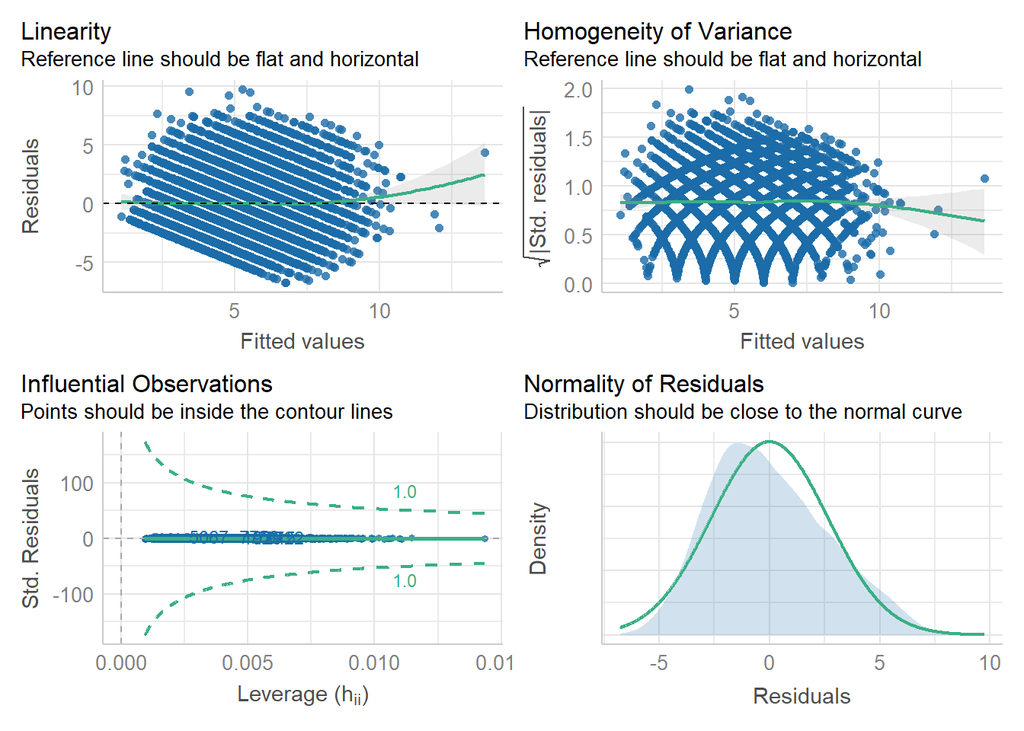

```r
performance::check_model(wls.model,check=c('linearity','normality','homogeneity','outliers'))
```

Compare MLR and weighted MLR

```r
performance::compare_performance(reg.last,wls.model)
```

```
## Some of the nested models seem to be identical
```

```
## # Comparison of Model Performance Indices
##
## Name      | Model |   AIC (weights) |  AICc (weights) |   BIC (weights) |    R2 | R2 (adj.) |  RMSE | Sigma
## -----------------------------------------------------------------------------------------------------------
## reg.last  |    lm | 38170.2 (<.001) | 38170.4 (<.001) | 38379.7 (<.001) | 0.243 |     0.240 | 2.651 | 2.656
## wls.model |    lm | 38103.3 (>.999) | 38103.5 (>.999) | 38312.8 (>.999) | 0.239 |     0.236 | 2.651 | 1.226
```

### Generate Table 2 of results of weighted MLR.

Results of weighted MLR, including coefficients’ estimations, 95% CIs and P values.

```r
tab_model(wls.model,show.ci = 0.95,show.p = TRUE,show.re.var = FALSE,show.ngroups = FALSE,
          show.aic = FALSE,show.r2=FALSE,digits = 3,digits.re = 3)
```

|  | zPSQI |  |  |
| --- | --- | --- | --- |
| Predictors | Estimates | CI | p |
| (Intercept) | -0.771 | -2.392 – 0.849 | 0.351 |
| gender [Male] | -0.086 | -0.225 – 0.052 | 0.222 |
| age | 0.139 | 0.056 – 0.222 | **0.001** |
| BMI | -0.021 | -0.037 – -0.005 | **0.009** |
| zCDRISC | -0.017 | -0.020 – -0.013 | **<0.001** |
| zMPAI | 0.044 | 0.040 – 0.049 | **<0.001** |
| grade | 0.177 | 0.066 – 0.287 | **0.002** |
| MedicalMajor [Yes] | -0.335 | -0.509 – -0.162 | **<0.001** |
| NativePlace [Urban] | -0.078 | -0.216 – 0.061 | 0.272 |
| OnlyChild [Yes] | -0.096 | -0.228 – 0.035 | 0.150 |
| FatherEducationLevel | -0.162 | -0.272 – -0.053 | **0.004** |
| MotherEducationLevel | 0.078 | -0.041 – 0.197 | 0.198 |
| FamilyEconomicLevel | -0.021 | -0.167 – 0.125 | 0.775 |
| MonthlyLivingExpense | -0.124 | -0.253 – 0.006 | 0.062 |
| smoking [Yes] | 0.953 | 0.629 – 1.277 | **<0.001** |
| drinking [Yes] | 0.382 | 0.245 – 0.519 | **<0.001** |
| PhysicalExercise | -0.054 | -0.162 – 0.054 | 0.326 |
| AcademicPressure | 0.319 | 0.184 – 0.455 | **<0.001** |
| EmploymentPressure | 0.183 | 0.087 – 0.280 | **<0.001** |
| RelationshipWithClassmates | 0.196 | 0.061 – 0.332 | **0.004** |
| RoommateSleepsLate [Yes] | 0.255 | 0.120 – 0.390 | **<0.001** |
| NoisyDormitory [Yes] | 0.554 | 0.393 – 0.716 | **<0.001** |
| DormitoryLight [Bright] | 0.006 | -0.132 – 0.143 | 0.936 |
| DormitoryHygiene [Poor] | -0.056 | -0.188 – 0.076 | 0.409 |
| AmativenessMatter [Ever] | 0.024 | -0.111 – 0.159 | 0.727 |
| AmativenessMatter [BeingInlove] | 0.008 | -0.154 – 0.169 | 0.927 |
| PhysicalHealthStatus | 0.459 | 0.331 – 0.587 | **<0.001** |
| MentalHealthStatus | 0.769 | 0.637 – 0.902 | **<0.001** |
| ReceivedPsychologicalCounseling [Yes] | 0.651 | 0.442 – 0.860 | **<0.001** |
| Observations | 7960 |  |  |

```r
estBeta <- wls.model$coefficients %>% round(.,digits = 3)
estBeta.ci <- wls.model %>% confint %>% round(.,digits = 3)
matrix(paste0(estBeta,' (',estBeta.ci[,1],', ',estBeta.ci[,2],')',
              round(summary(wls.model)$coefficients[,'t value'],3),' ',
              round(summary(wls.model)$coefficients[,'Pr(>|t|)'],3)),
       dim(estBeta.ci),dimnames = dimnames(estBeta.ci)[1])
```

```
##                                    [,1]
## (Intercept)                        "-0.771 (-2.392, 0.849)-0.933 0.351"
## genderMale                         "-0.086 (-0.225, 0.052)-1.221 0.222"
## age                                "0.139 (0.056, 0.222)3.3 0.001"
## BMI                                "-0.021 (-0.037, -0.005)-2.601 0.009"
## zCDRISC                            "-0.017 (-0.02, -0.013)-9.344 0"
## zMPAI                              "0.044 (0.04, 0.049)18.45 0"
## grade                              "0.177 (0.066, 0.287)3.128 0.002"
## MedicalMajorYes                    "-0.335 (-0.509, -0.162)-3.796 0"
## NativePlaceUrban                   "-0.078 (-0.216, 0.061)-1.099 0.272"
## OnlyChildYes                       "-0.096 (-0.228, 0.035)-1.44 0.15"
## FatherEducationLevel               "-0.162 (-0.272, -0.053)-2.907 0.004"
## MotherEducationLevel               "0.078 (-0.041, 0.197)1.287 0.198"
## FamilyEconomicLevel                "-0.021 (-0.167, 0.125)-0.286 0.775"
## MonthlyLivingExpense               "-0.124 (-0.253, 0.006)-1.866 0.062"
## smokingYes                         "0.953 (0.629, 1.277)5.768 0"
## drinkingYes                        "0.382 (0.245, 0.519)5.471 0"
## PhysicalExercise                   "-0.054 (-0.162, 0.054)-0.982 0.326"
## AcademicPressure                   "0.319 (0.184, 0.455)4.606 0"
## EmploymentPressure                 "0.183 (0.087, 0.28)3.729 0"
## RelationshipWithClassmates         "0.196 (0.061, 0.332)2.851 0.004"
## RoommateSleepsLateYes              "0.255 (0.12, 0.39)3.697 0"
## NoisyDormitoryYes                  "0.554 (0.393, 0.716)6.734 0"
## DormitoryLightBright               "0.006 (-0.132, 0.143)0.08 0.936"
## DormitoryHygienePoor               "-0.056 (-0.188, 0.076)-0.826 0.409"
## AmativenessMatterEver              "0.024 (-0.111, 0.159)0.349 0.727"
## AmativenessMatterBeingInlove       "0.008 (-0.154, 0.169)0.092 0.927"
## PhysicalHealthStatus               "0.459 (0.331, 0.587)7.038 0"
## MentalHealthStatus                 "0.769 (0.637, 0.902)11.367 0"
## ReceivedPsychologicalCounselingYes "0.651 (0.442, 0.86)6.102 0"
```

Linear trend test for continuous variables in weighted MLR.

```r
mydata.out <- mydata.out %>% mutate(
  age.ord = factor(cut(age,breaks = 4,labels=c(1,2,3,4)),ordered = T),
  BMI.ord = factor(cut(BMI,breaks = 4,labels=c(1,2,3,4)),ordered = T),
  zCDRISC.ord = factor(cut(zCDRISC,breaks = 4,labels=c(1,2,3,4)),ordered = T),
  zMPAI.ord = factor(cut(zMPAI,breaks = 4,labels=c(1,2,3,4)),ordered = T),
)

summary(update(wls.model, . ~ . - age + age.ord))$coefficients[c('age.ord.L','age.ord.Q'),]
```

```
##           Estimate Std. Error t value Pr(>|t|)
## age.ord.L   0.3084     0.1216   2.536  0.01124
## age.ord.Q   0.0956     0.0914   1.046  0.29566
```

```r
summary(update(wls.model, . ~ . - BMI + BMI.ord))$coefficients[c('BMI.ord.L','BMI.ord.Q'),]
```

```
##           Estimate Std. Error t value Pr(>|t|)
## BMI.ord.L -0.61901     0.3650  -1.696  0.08998
## BMI.ord.Q  0.09464     0.2751   0.344  0.73082
```

```r
summary(update(wls.model, . ~ . - zCDRISC + zCDRISC.ord))$coefficients[c('zCDRISC.ord.L','zCDRISC.ord.Q'),]
```

```
##               Estimate Std. Error t value  Pr(>|t|)
## zCDRISC.ord.L  -0.6785     0.1401  -4.843 1.305e-06
## zCDRISC.ord.Q  -0.2029     0.1122  -1.808 7.058e-02
```

```r
summary(update(wls.model, . ~ . - zMPAI + zMPAI.ord))$coefficients[c('zMPAI.ord.L','zMPAI.ord.Q'),]
```

```
##             Estimate Std. Error t value  Pr(>|t|)
## zMPAI.ord.L  1.46502     0.1292 11.3354 1.478e-29
## zMPAI.ord.Q -0.07226     0.1010 -0.7156 4.743e-01
```

```r
summary(update(wls.model, . ~ . - FatherEducationLevel + FatherEducationLevel.ord))$coefficients[c('FatherEducationLevel.ord.L','FatherEducationLevel.ord.Q'),]
```

```
##                            Estimate Std. Error t value Pr(>|t|)
## FatherEducationLevel.ord.L -0.23902    0.08091  -2.954 0.003146
## FatherEducationLevel.ord.Q -0.03713    0.06889  -0.539 0.589889
```

```r
summary(update(wls.model, . ~ . - AcademicPressure + AcademicPressure.ord))$coefficients[c('AcademicPressure.ord.L','AcademicPressure.ord.Q'),]
```

```
##                        Estimate Std. Error t value  Pr(>|t|)
## AcademicPressure.ord.L  0.46686    0.11559  4.0388 5.424e-05
## AcademicPressure.ord.Q -0.01657    0.06729 -0.2463 8.055e-01
```

```r
summary(update(wls.model, . ~ . - EmploymentPressure + EmploymentPressure.ord))$coefficients[c('EmploymentPressure.ord.L','EmploymentPressure.ord.Q'),]
```

```
##                          Estimate Std. Error t value  Pr(>|t|)
## EmploymentPressure.ord.L   0.2557    0.06987  3.6603 0.0002536
## EmploymentPressure.ord.Q   0.0291    0.04981  0.5842 0.5590857
```

```r
summary(update(wls.model, . ~ . - RelationshipWithClassmates + RelationshipWithClassmates.ord))$coefficients[c('RelationshipWithClassmates.ord.L','RelationshipWithClassmates.ord.Q'),]
```

```
##                                  Estimate Std. Error t value Pr(>|t|)
## RelationshipWithClassmates.ord.L  0.41707     0.2265  1.8412  0.06563
## RelationshipWithClassmates.ord.Q  0.09341     0.1372  0.6807  0.49607
```

```r
summary(update(wls.model, . ~ . - PhysicalHealthStatus + PhysicalHealthStatus.ord))$coefficients[c('PhysicalHealthStatus.ord.L','PhysicalHealthStatus.ord.Q'),]
```

```
##                            Estimate Std. Error t value  Pr(>|t|)
## PhysicalHealthStatus.ord.L  0.74391    0.12907   5.764 8.537e-09
## PhysicalHealthStatus.ord.Q  0.08125    0.07775   1.045 2.960e-01
```

```r
summary(update(wls.model, . ~ . - MentalHealthStatus + MentalHealthStatus.ord))$coefficients[c('MentalHealthStatus.ord.L','MentalHealthStatus.ord.Q'),]
```

```
##                          Estimate Std. Error t value  Pr(>|t|)
## MentalHealthStatus.ord.L  1.12012    0.12670  8.8408 1.156e-18
## MentalHealthStatus.ord.Q  0.02944    0.07644  0.3851 7.001e-01
```

### Binary logistic regression (BLR)

The diagnostics were processed with the following steps:

1. Extreme values were detected by the same method as MLR.
2. Detect multicollinearity by VIF.
3. The independence of observations by Durbin-Waston’s test.
4. Check linearity between the log odds and explanatory variables.
5. Check overdispersion.
6. Events per variable (EPV).

```r
reg.formula.logi <- update(reg.formula,zPSQI.cat ~ .)
shuimian.logi <- glm(
  formula = reg.formula.logi,
  family  = binomial(link = "logit"),
  data    = mydata
)
```

Remove outliers.

```r
outlierResult <- car::outlierTest(shuimian.logi)
if (outlierResult$bonf.p[1] < 0.05) {
  exclusionRows   <- names(outlierResult[[1]])
  inclusionRows   <- !(rownames(mydata) %in% exclusionRows)
  mydata.logi.out <- mydata[inclusionRows,]
  logi.last       <- glm(formula = reg.formula.logi,family  = binomial(link = "logit"), data = mydata.logi.out)
} else {logi.last <- shuimian.logi;mydata.logi.out <- mydata}
```

Remove high leverage points.

```r
leverage.con <- names(which(hatvalues(logi.last) >
                              3 * length(coefficients(logi.last))/length(fitted(logi.last))))
if (length(leverage.con) > 0) {
  exclusionRows   <- leverage.con
  inclusionRows   <- !(rownames(mydata.logi.out) %in% exclusionRows)
  mydata.logi.out <- mydata.logi.out[inclusionRows,]
  logi.last       <- glm(formula = reg.formula.logi,family  = binomial(link = "logit"), data = mydata.logi.out)
}
```

Remove influential points.

```r
influential <- which(cooks.distance(logi.last)
                     > 4/(nrow(mydata.logi.out)-length(logi.last$coefficients)-2))
if (length(influential) > 0){
  exclusionRows <- rownames(mydata.logi.out)[influential]
  inclusionRows <- !(rownames(mydata.logi.out) %in% exclusionRows)
  mydata.logi.out <- mydata.logi.out[inclusionRows,]
  logi.last <- glm(formula = reg.formula.logi,family  = binomial(link = "logit"), data = mydata.logi.out)
}

cat("Number of removed samples:",dim(mydata)[1] - dim(mydata.logi.out)[1])
```

```
## Number of removed samples: 408
```

The independence of observations was performed by Durbin-Waston’s test.

```r
performance::check_autocorrelation(logi.last)
```

```
## OK: Residuals appear to be independent and not autocorrelated (p = 0.564).
```

### Plot Figure S2 of extreme values.

Performance of extreme values after diagnostics.

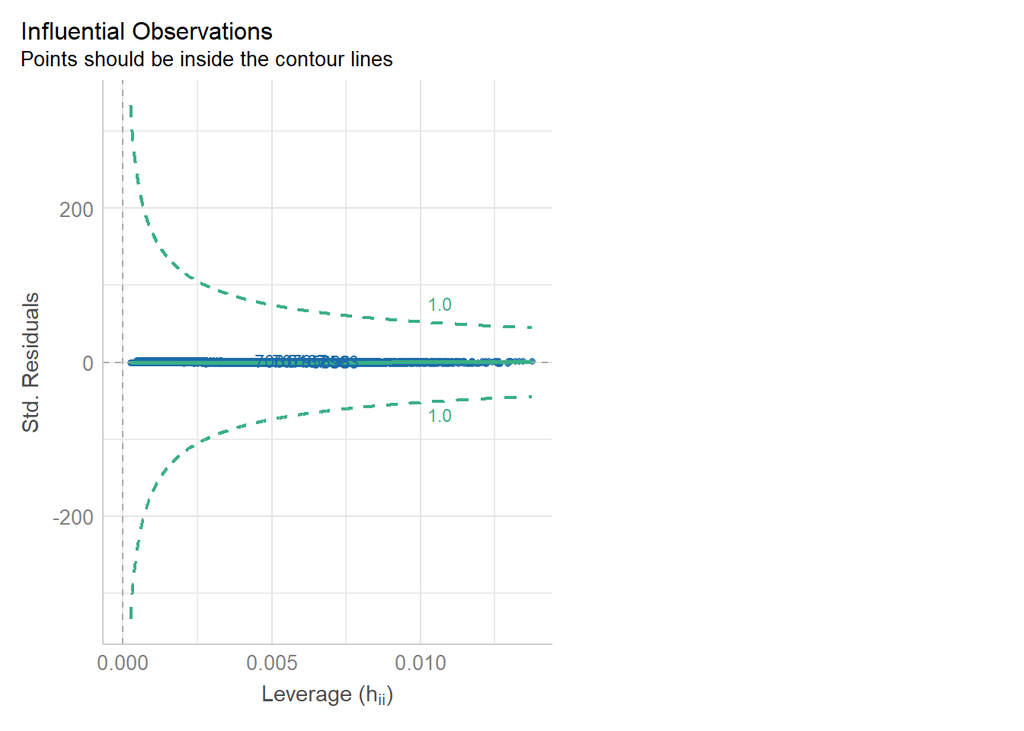

```r
performance::check_model(logi.last,check=c('outliers'))
```

### Plot Figure S2 of linearity.

Check linearity between the log odds and explanatory variables with regressing the log odds against the explanatory variables.

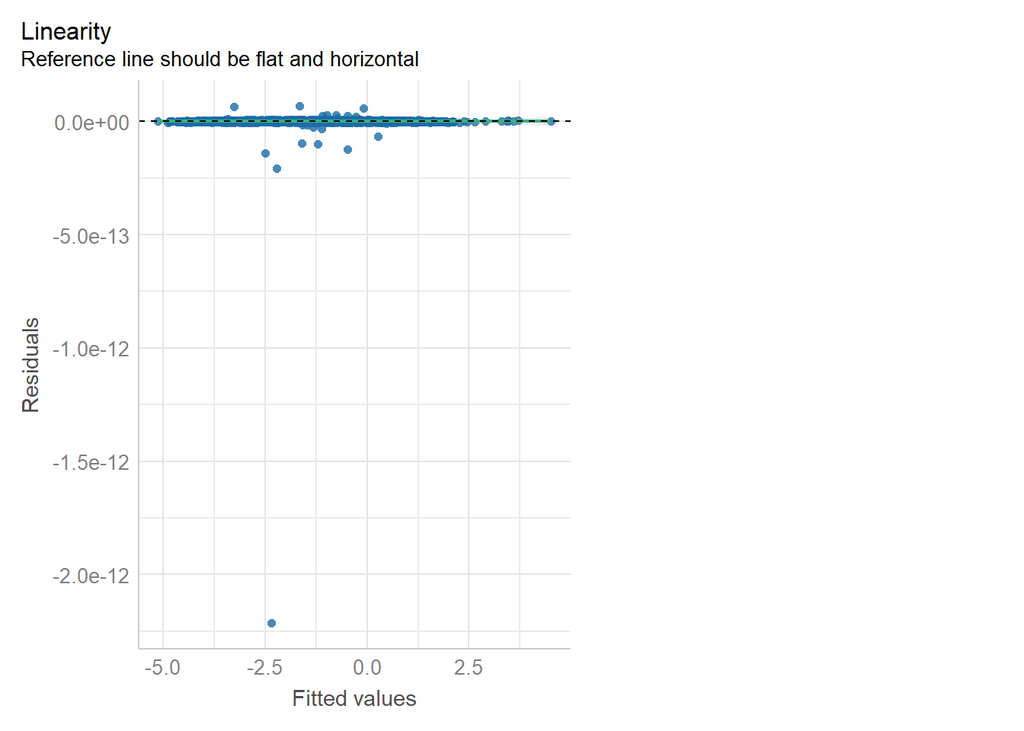

```r
mydata.logi.out <- mydata.logi.out %>% mutate(
  prob = predict(logi.last,type = 'response'),
  logitP = log(prob/(1-prob))
)

reg.formula.logi.linear <- update(reg.formula, logitP ~ .)
logi.linear <- lm(formula = reg.formula.logi.linear, data = mydata.logi.out)
performance::check_model(logi.linear,check=c('linearity'))
```

### Generate Table 2 of results of BLR.

BLR results in Table 2, including ORs, 95%CIs, and P values.

```r
tab_model(logi.last,show.ci = 0.95,show.p = TRUE,show.re.var = FALSE,show.ngroups = FALSE,
          show.aic = FALSE,show.r2=FALSE,digits = 3,digits.re = 3)
```

|  | zPSQI.cat |  |  |
| --- | --- | --- | --- |
| Predictors | Odds Ratios | CI | p |
| (Intercept) | 0.007 | 0.001 – 0.034 | **<0.001** |
| gender [Male] | 0.892 | 0.774 – 1.026 | 0.112 |
| age | 1.080 | 0.996 – 1.170 | 0.062 |
| BMI | 0.959 | 0.943 – 0.975 | **<0.001** |
| zCDRISC | 0.986 | 0.982 – 0.990 | **<0.001** |
| zMPAI | 1.036 | 1.031 – 1.041 | **<0.001** |
| grade | 1.178 | 1.059 – 1.310 | **0.003** |
| MedicalMajor [Yes] | 0.675 | 0.559 – 0.813 | **<0.001** |
| NativePlace [Urban] | 0.932 | 0.811 – 1.071 | 0.323 |
| OnlyChild [Yes] | 0.811 | 0.710 – 0.926 | **0.002** |
| FatherEducationLevel | 0.777 | 0.690 – 0.873 | **<0.001** |
| MotherEducationLevel | 1.214 | 1.072 – 1.375 | **0.002** |
| FamilyEconomicLevel | 1.098 | 0.952 – 1.267 | 0.198 |
| MonthlyLivingExpense | 0.891 | 0.784 – 1.012 | 0.075 |
| smoking [Yes] | 1.568 | 1.195 – 2.052 | **0.001** |
| drinking [Yes] | 1.255 | 1.101 – 1.431 | **0.001** |
| PhysicalExercise | 0.963 | 0.866 – 1.071 | 0.485 |
| AcademicPressure | 1.177 | 1.036 – 1.337 | **0.012** |
| EmploymentPressure | 1.226 | 1.114 – 1.349 | **<0.001** |
| RelationshipWithClassmates | 1.021 | 0.906 – 1.151 | 0.730 |
| RoommateSleepsLate [Yes] | 1.141 | 1.000 – 1.301 | **0.049** |
| NoisyDormitory [Yes] | 1.543 | 1.332 – 1.787 | **<0.001** |
| DormitoryLight [Bright] | 0.950 | 0.829 – 1.087 | 0.454 |
| DormitoryHygiene [Poor] | 0.979 | 0.863 – 1.112 | 0.749 |
| AmativenessMatter [Ever] | 1.024 | 0.896 – 1.170 | 0.727 |
| AmativenessMatter [BeingInlove] | 1.117 | 0.953 – 1.309 | 0.171 |
| PhysicalHealthStatus | 1.331 | 1.178 – 1.505 | **<0.001** |
| MentalHealthStatus | 2.028 | 1.796 – 2.292 | **<0.001** |
| ReceivedPsychologicalCounseling [Yes] | 1.383 | 1.169 – 1.633 | **<0.001** |
| Observations | 8049 |  |  |

```r
estBeta <- logi.last$coefficients %>% exp %>% round(.,digits = 3)
estBeta.ci <- logi.last %>% confint %>% exp  %>% round(.,digits = 3)
matrix(paste0(estBeta,' (',estBeta.ci[,1],', ',estBeta.ci[,2],')',
              round(summary(logi.last)$coefficients[,'Pr(>|z|)'],3)),dim(estBeta.ci),dimnames = dimnames(estBeta.ci)[1])
```

```
##                                    [,1]
## (Intercept)                        "0.007 (0.001, 0.034)0"
## genderMale                         "0.892 (0.774, 1.026)0.112"
## age                                "1.08 (0.996, 1.17)0.062"
## BMI                                "0.959 (0.943, 0.975)0"
## zCDRISC                            "0.986 (0.982, 0.99)0"
## zMPAI                              "1.036 (1.031, 1.041)0"
## grade                              "1.178 (1.059, 1.31)0.003"
## MedicalMajorYes                    "0.675 (0.559, 0.813)0"
## NativePlaceUrban                   "0.932 (0.811, 1.071)0.323"
## OnlyChildYes                       "0.811 (0.71, 0.926)0.002"
## FatherEducationLevel               "0.777 (0.69, 0.873)0"
## MotherEducationLevel               "1.214 (1.072, 1.375)0.002"
## FamilyEconomicLevel                "1.098 (0.952, 1.267)0.198"
## MonthlyLivingExpense               "0.891 (0.784, 1.012)0.075"
## smokingYes                         "1.568 (1.195, 2.052)0.001"
## drinkingYes                        "1.255 (1.101, 1.431)0.001"
## PhysicalExercise                   "0.963 (0.866, 1.071)0.485"
## AcademicPressure                   "1.177 (1.036, 1.337)0.012"
## EmploymentPressure                 "1.226 (1.114, 1.349)0"
## RelationshipWithClassmates         "1.021 (0.906, 1.151)0.73"
## RoommateSleepsLateYes              "1.141 (1, 1.301)0.049"
## NoisyDormitoryYes                  "1.543 (1.332, 1.787)0"
## DormitoryLightBright               "0.95 (0.829, 1.087)0.454"
## DormitoryHygienePoor               "0.979 (0.863, 1.112)0.749"
## AmativenessMatterEver              "1.024 (0.896, 1.17)0.727"
## AmativenessMatterBeingInlove       "1.117 (0.953, 1.309)0.171"
## PhysicalHealthStatus               "1.331 (1.178, 1.505)0"
## MentalHealthStatus                 "2.028 (1.796, 2.292)0"
## ReceivedPsychologicalCounselingYes "1.383 (1.169, 1.633)0"
```

Overdispersion detection by likelihood ratio test.

```r
logi.quasi.last <- glm(formula = reg.formula.logi,family  = quasibinomial(link = "logit"), data = mydata.logi.out)
pchisq(summary(logi.quasi.last)$dispersion * logi.last$df.residual,
       logi.last$df.residual, lower = F)
```

```
## [1] 0.9999
```

### Plot Figure 1 (a)

Sorted ORs of BLR.

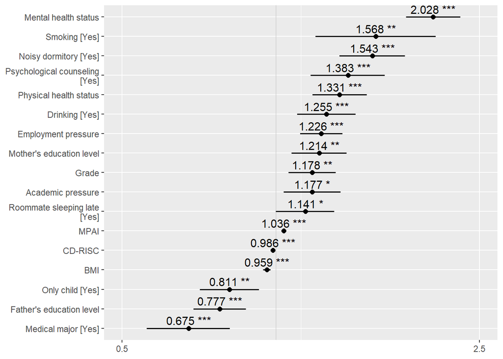

```r
plot_model(logi.last
           ,vline.color = "grey"
           ,show.values = TRUE, value.offset = .4
           ,sort.est=T
           ,digits = 3
           ,rm.terms=c('AmativenessMatter [BeingInlove]',
                       'FamilyEconomicLevel','age',
                       'AmativenessMatter [Ever]',
                       'RelationshipWithClassmates',
                       'DormitoryHygiene [Poor]',
                       'PhysicalExercise',
                       'DormitoryLight [Bright]',
                       'NativePlace [Urban]',
                       'gender [Male]','MonthlyLivingExpense')
           ,title = ''
           ,axis.title =''
           ,colors = "black"
           ,grid.breaks = c(0.5,2.5)
           ,dot.size=2
           ,axis.labels = c(MentalHealthStatus = 'Mental health status',
                            PhysicalHealthStatus = 'Physical health status',
                            EmploymentPressure = 'Employment pressure',
                            MotherEducationLevel = "Mother's education level",
                            grade = 'Grade',
                            AcademicPressure = 'Academic pressure',
                            zMPAI = 'MPAI',
                            zCDRISC = 'CD-RISC',
                            smokingYes = 'Smoking [Yes]',
                            NoisyDormitoryYes = 'Noisy dormitory [Yes]',
                            ReceivedPsychologicalCounselingYes = 'Psychological counseling [Yes]',
                            drinkingYes = 'Drinking [Yes]',
                            RoommateSleepsLateYes = 'Roommate sleeping late [Yes]',
                            OnlyChildYes = 'Only child [Yes]',
                            FatherEducationLevel = "Father's education level",
                            MedicalMajorYes = 'Medical major [Yes]')
           )
```

Linear trend test for continuous variables in BLR.

```r
mydata.logi.out <- mydata.logi.out %>% mutate(
  BMI.ord = factor(cut(BMI,breaks = 4,labels=c(1,2,3,4)),ordered = T),
  zCDRISC.ord = factor(cut(zCDRISC,breaks = 4,labels=c(1,2,3,4)),ordered = T),
  zMPAI.ord = factor(cut(zMPAI,breaks = 4,labels=c(1,2,3,4)),ordered = T),
)

summary(update(logi.last, . ~ . - BMI + BMI.ord))$coefficients[c('BMI.ord.L','BMI.ord.Q'),]
summary(update(logi.last, . ~ . - zCDRISC + zCDRISC.ord))$coefficients[c('zCDRISC.ord.L','zCDRISC.ord.Q'),]
summary(update(logi.last, . ~ . - zMPAI + zMPAI.ord))$coefficients[c('zMPAI.ord.L','zMPAI.ord.Q'),]
summary(update(logi.last, . ~ . - grade + grade.ord))$coefficients[c('grade.ord.L','grade.ord.Q'),]
summary(update(logi.last, . ~ . - FatherEducationLevel + FatherEducationLevel.ord))$coefficients[c('FatherEducationLevel.ord.L','FatherEducationLevel.ord.Q'),]
summary(update(logi.last, . ~ . - MotherEducationLevel + MotherEducationLevel.ord))$coefficients[c('MotherEducationLevel.ord.L','MotherEducationLevel.ord.Q'),]
summary(update(logi.last, . ~ . - AcademicPressure + AcademicPressure.ord))$coefficients[c('AcademicPressure.ord.L','AcademicPressure.ord.Q'),]
summary(update(logi.last, . ~ . - EmploymentPressure + EmploymentPressure.ord))$coefficients[c('EmploymentPressure.ord.L','EmploymentPressure.ord.Q'),]
summary(update(logi.last, . ~ . - PhysicalHealthStatus + PhysicalHealthStatus.ord))$coefficients[c('PhysicalHealthStatus.ord.L','PhysicalHealthStatus.ord.Q'),]
summary(update(logi.last, . ~ . - MentalHealthStatus + MentalHealthStatus.ord))$coefficients[c('MentalHealthStatus.ord.L','MentalHealthStatus.ord.Q'),]
```

```
##           Estimate Std. Error z value  Pr(>|z|)
## BMI.ord.L  -1.2782     0.3624 -3.5267 0.0004208
## BMI.ord.Q  -0.1003     0.2733 -0.3668 0.7137343
##               Estimate Std. Error z value  Pr(>|z|)
## zCDRISC.ord.L  -0.5924     0.1473  -4.021 5.793e-05
## zCDRISC.ord.Q  -0.2639     0.1133  -2.331 1.978e-02
##             Estimate Std. Error z value  Pr(>|z|)
## zMPAI.ord.L   1.1174    0.10731  10.413 2.157e-25
## zMPAI.ord.Q  -0.1688    0.08427  -2.003 4.513e-02
##             Estimate Std. Error z value Pr(>|z|)
## grade.ord.L   0.2129     0.1311   1.624  0.10432
## grade.ord.Q  -0.1619     0.0984  -1.645  0.09997
##                            Estimate Std. Error z value  Pr(>|z|)
## FatherEducationLevel.ord.L -0.37074    0.08824 -4.2015 2.652e-05
## FatherEducationLevel.ord.Q -0.04127    0.07264 -0.5682 5.699e-01
##                            Estimate Std. Error z value Pr(>|z|)
## MotherEducationLevel.ord.L  0.24508    0.09338   2.625 0.008675
## MotherEducationLevel.ord.Q -0.09449    0.07619  -1.240 0.214905
##                        Estimate Std. Error z value Pr(>|z|)
## AcademicPressure.ord.L  0.31235    0.14706  2.1240  0.03367
## AcademicPressure.ord.Q -0.06275    0.08702 -0.7211  0.47084
##                          Estimate Std. Error z value  Pr(>|z|)
## EmploymentPressure.ord.L  0.31733    0.07360   4.311 1.623e-05
## EmploymentPressure.ord.Q -0.06706    0.05395  -1.243 2.139e-01
##                            Estimate Std. Error z value  Pr(>|z|)
## PhysicalHealthStatus.ord.L  0.41904    0.10218  4.1010 4.114e-05
## PhysicalHealthStatus.ord.Q  0.01703    0.06204  0.2745 7.837e-01
##                          Estimate Std. Error z value  Pr(>|z|)
## MentalHealthStatus.ord.L  0.94965    0.09758   9.732 2.212e-22
## MentalHealthStatus.ord.Q -0.07005    0.05851  -1.197 2.312e-01
```

### Plot Figure S5.

linear and quadratic trend between MPAI and PSQI in BLR.

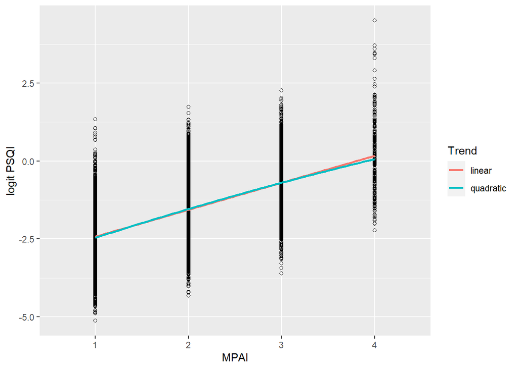

```r
ggplot(mydata.logi.out) +
  aes(x = zMPAI.ord, y = logitP) +
  geom_point(shape = 1) +
  geom_smooth(aes(x = unclass(zMPAI.ord), color = "1"),
              formula = y ~ x,
              method = lm, se = FALSE) +
  geom_smooth(aes(x = unclass(zMPAI.ord), color = "2"),
              formula = y ~ x + poly(x, 2),
              method = lm, se = FALSE) +
  scale_color_discrete("Trend", labels = c("linear", "quadratic")) +
  labs(x = 'MPAI',y = 'logit PSQI')
```

### Plot Figure S6.

ROC of BLR.

```r
predict_<-predict.glm(logi.last,type='response',newdata = mydata.logi.out)
modelroc <- roc(mydata.logi.out$zPSQI.cat,predict_)
```

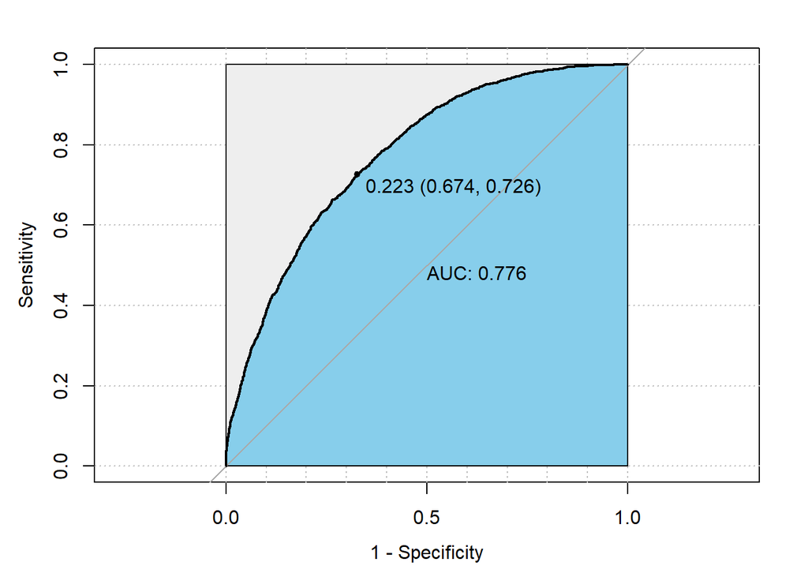

```r
plot(modelroc
     ,print.auc=TRUE
     ,auc.polygon=TRUE
     ,legacy.axes=TRUE
     ,grid=c(0.1, 0.2)
     ,grid.col=c("grey", "grey")
     ,max.auc.polygon=TRUE
     ,auc.polygon.col="skyblue"
     ,print.thres=TRUE
)
```

### Weighted linear mixed model (Weighted LMM)

The regression diagnostics were processed with the following steps:

1. Multicollinearity.
2. Outliers.
3. Homoscedasticity of residuals.
4. Detect the normality of residuals.
5. Linearity.

```r
mixed.reg.formula <- as.formula(
  zPSQI ~ gender + age + BMI + NativePlace + OnlyChild + FatherEducationLevel + MotherEducationLevel + FamilyEconomicLevel + MonthlyLivingExpense + PhysicalExercise + RoommateSleepsLate + NoisyDormitory + DormitoryLight + DormitoryHygiene + RelationshipWithClassmates + AmativenessMatter + MedicalMajor + zCDRISC + zMPAI
+ (1 |grade.ord) + (1 |smoking) + (1 |drinking) + (1 |PhysicalHealthStatus.ord) + (1 |MentalHealthStatus.ord) + (1 + RelationshipWithClassmates|AcademicPressure.ord) + (1 + RelationshipWithClassmates|EmploymentPressure.ord) + (1 |ReceivedPsychologicalCounseling))

mixedmodel <- lmer(
  data = mydata
  ,formula = mixed.reg.formula
  ,control = lmerControl(optimizer = "bobyqa"))
```

Detect outliers for LMM.

```r
performance::check_outliers(mixedmodel)
```

```
## OK: No outliers detected.
## - Based on the following method and threshold: cook (0.94).
## - For variable: (Whole model)
```

Detect multicollinearity.

```r
performance::check_collinearity(mixedmodel)
```

```
## # Check for Multicollinearity
##
## Low Correlation
##
##                        Term  VIF    VIF 95% CI Increased SE Tolerance
##                      gender 1.11 [1.09,  1.14]         1.06      0.90
##                         age 1.03 [1.01,  1.06]         1.01      0.97
##                         BMI 1.04 [1.02,  1.07]         1.02      0.96
##                 NativePlace 1.36 [1.33,  1.40]         1.17      0.73
##                   OnlyChild 1.22 [1.19,  1.25]         1.10      0.82
##        FatherEducationLevel 1.94 [1.88,  2.00]         1.39      0.52
##        MotherEducationLevel 1.94 [1.88,  2.00]         1.39      0.52
##         FamilyEconomicLevel 1.26 [1.23,  1.29]         1.12      0.79
##        MonthlyLivingExpense 1.27 [1.23,  1.30]         1.12      0.79
##            PhysicalExercise 1.04 [1.03,  1.07]         1.02      0.96
##          RoommateSleepsLate 1.28 [1.25,  1.32]         1.13      0.78
##              NoisyDormitory 1.36 [1.32,  1.39]         1.16      0.74
##              DormitoryLight 1.13 [1.11,  1.16]         1.07      0.88
##            DormitoryHygiene 1.05 [1.03,  1.08]         1.02      0.95
##  RelationshipWithClassmates 1.00 [1.00, 21.57]         1.00      1.00
##           AmativenessMatter 1.03 [1.01,  1.06]         1.01      0.97
##                MedicalMajor 1.01 [1.00,  1.08]         1.01      0.99
##                     zCDRISC 1.03 [1.01,  1.06]         1.01      0.97
##                       zMPAI 1.04 [1.02,  1.07]         1.02      0.96
##  Tolerance 95% CI
##      [0.87, 0.92]
##      [0.94, 0.99]
##      [0.94, 0.98]
##      [0.71, 0.75]
##      [0.80, 0.84]
##      [0.50, 0.53]
##      [0.50, 0.53]
##      [0.77, 0.81]
##      [0.77, 0.81]
##      [0.93, 0.98]
##      [0.76, 0.80]
##      [0.72, 0.76]
##      [0.86, 0.90]
##      [0.93, 0.97]
##      [0.05, 1.00]
##      [0.94, 0.99]
##      [0.92, 1.00]
##      [0.94, 0.99]
##      [0.94, 0.98]
```

Check independence of residuals by Durbin-Waston’s test.

```r
performance::check_autocorrelation(mixedmodel)
```

```
## OK: Residuals appear to be independent and not autocorrelated (p = 0.182).
```

Check heteroscedasticity of residuals.

```r
performance::check_heteroscedasticity(mixedmodel)
```

[output not shown]

Implement weighted LMM. Define weightes as weighted MLR.

```r
wt <- 1 / lm(abs(summary(mixedmodel)$residuals) ~ predict(mixedmodel))$fitted.values^2
mixedmodel.wt <- lmer(
  data     = mydata
  ,formula = mixed.reg.formula
  ,weights = wt
  ,control = lmerControl(optimizer = "bobyqa")
  )
```

Check significance of random effects by likelihood ratio test.

```r
ranova(mixedmodel.wt)
```

```
## ANOVA-like table for random-effects: Single term deletions
##
## Model:
## zPSQI ~ gender + age + BMI + NativePlace + OnlyChild + FatherEducationLevel + MotherEducationLevel + FamilyEconomicLevel + MonthlyLivingExpense + PhysicalExercise + RoommateSleepsLate + NoisyDormitory + DormitoryLight + DormitoryHygiene + RelationshipWithClassmates + AmativenessMatter + MedicalMa…
##                                                                                         npar
## <none>                                                                                    34
## (1 | grade.ord)                                                                           33
## (1 | smoking)                                                                             33
## (1 | drinking)                                                                            33
## (1 | PhysicalHealthStatus.ord)                                                            33
## (1 | MentalHealthStatus.ord)                                                              33
## RelationshipWithClassmates in (1 + RelationshipWithClassmates | AcademicPressure.ord)     32
## RelationshipWithClassmates in (1 + RelationshipWithClassmates | EmploymentPressure.ord)   32
## (1 | ReceivedPsychologicalCounseling)                                                     33
##                                                                                         logLik
## <none>                                                                                  -21783
## (1 | grade.ord)                                                                         -21791
## (1 | smoking)                                                                           -21792
## (1 | drinking)                                                                          -21794
## (1 | PhysicalHealthStatus.ord)                                                          -21811
## (1 | MentalHealthStatus.ord)                                                            -21837
## RelationshipWithClassmates in (1 + RelationshipWithClassmates | AcademicPressure.ord)   -21787
## RelationshipWithClassmates in (1 + RelationshipWithClassmates | EmploymentPressure.ord) -21785
## (1 | ReceivedPsychologicalCounseling)                                                   -21794
##                                                                                           AIC
## <none>                                                                                  43635
## (1 | grade.ord)                                                                         43648
## (1 | smoking)                                                                           43649
## (1 | drinking)                                                                          43655
## (1 | PhysicalHealthStatus.ord)                                                          43689
## (1 | MentalHealthStatus.ord)                                                            43740
## RelationshipWithClassmates in (1 + RelationshipWithClassmates | AcademicPressure.ord)   43638
## RelationshipWithClassmates in (1 + RelationshipWithClassmates | EmploymentPressure.ord) 43634
## (1 | ReceivedPsychologicalCounseling)                                                   43654
##                                                                                           LRT
## <none>
## (1 | grade.ord)                                                                          15.3
## (1 | smoking)                                                                            16.5
## (1 | drinking)                                                                           21.7
## (1 | PhysicalHealthStatus.ord)                                                           56.0
```

[output cut: 21 more lines]

```
## RelationshipWithClassmates in (1 + RelationshipWithClassmates | AcademicPressure.ord)         0.03
## RelationshipWithClassmates in (1 + RelationshipWithClassmates | EmploymentPressure.ord)       0.21
## (1 | ReceivedPsychologicalCounseling)                                                      3.9e-06
##
## <none>
## (1 | grade.ord)                                                                         ***
## (1 | smoking)                                                                           ***
## (1 | drinking)                                                                          ***
## (1 | PhysicalHealthStatus.ord)                                                          ***
## (1 | MentalHealthStatus.ord)                                                            ***
## RelationshipWithClassmates in (1 + RelationshipWithClassmates | AcademicPressure.ord)   *
## RelationshipWithClassmates in (1 + RelationshipWithClassmates | EmploymentPressure.ord)
## (1 | ReceivedPsychologicalCounseling)                                                   ***
## ---
## Signif. codes:  0 '***' 0.001 '**' 0.01 '*' 0.05 '.' 0.1 ' ' 1
```

```r
mixedmodel.wt.rwcep <- update(mixedmodel.wt
                            , . ~ . - (1 + RelationshipWithClassmates|EmploymentPressure.ord)
                            + (1 | EmploymentPressure.ord))
mixedmodel.wt.ep <- update(mixedmodel.wt.rwcep
                              , . ~ . - (1 | EmploymentPressure.ord))
anova(mixedmodel.wt.rwcep,mixedmodel.wt.ep)
```

```
## refitting model(s) with ML (instead of REML)
```

```
## Data: mydata
## Models:
## mixedmodel.wt.ep: zPSQI ~ gender + age + BMI + NativePlace + OnlyChild + FatherEducationLevel + MotherEducationLevel + FamilyEconomicLevel + MonthlyLivingExpense + PhysicalExercise + RoommateSleepsLate + NoisyDormitory + DormitoryLight + DormitoryHygiene + RelationshipWithClassmates + Amativeness…
## mixedmodel.wt.rwcep: zPSQI ~ gender + age + BMI + NativePlace + OnlyChild + FatherEducationLevel + MotherEducationLevel + FamilyEconomicLevel + MonthlyLivingExpense + PhysicalExercise + RoommateSleepsLate + NoisyDormitory + DormitoryLight + DormitoryHygiene + RelationshipWithClassmates + Amativen…
##                     npar   AIC   BIC logLik deviance Chisq Df Pr(>Chisq)
## mixedmodel.wt.ep      31 43558 43776 -21748    43496
## mixedmodel.wt.rwcep   32 43553 43778 -21744    43489  7.35  1     0.0067 **
## ---
## Signif. codes:  0 '***' 0.001 '**' 0.01 '*' 0.05 '.' 0.1 ' ' 1
```

```r
mixedmodel.wt.rwcap <- update(mixedmodel.wt
                              , . ~ . - (1 + RelationshipWithClassmates|AcademicPressure.ord)
                              + (1 | AcademicPressure.ord))
mixedmodel.wt.ap <- update(mixedmodel.wt.rwcep
                           , . ~ . - (1 | AcademicPressure.ord))
anova(mixedmodel.wt.rwcap,mixedmodel.wt.ap)
```

```
## refitting model(s) with ML (instead of REML)
```

```
## Data: mydata
## Models:
## mixedmodel.wt.rwcap: zPSQI ~ gender + age + BMI + NativePlace + OnlyChild + FatherEducationLevel + MotherEducationLevel + FamilyEconomicLevel + MonthlyLivingExpense + PhysicalExercise + RoommateSleepsLate + NoisyDormitory + DormitoryLight + DormitoryHygiene + RelationshipWithClassmates + Amativen…
## mixedmodel.wt.ap: zPSQI ~ gender + age + BMI + NativePlace + OnlyChild + FatherEducationLevel + MotherEducationLevel + FamilyEconomicLevel + MonthlyLivingExpense + PhysicalExercise + RoommateSleepsLate + NoisyDormitory + DormitoryLight + DormitoryHygiene + RelationshipWithClassmates + Amativeness…
##                     npar   AIC   BIC logLik deviance Chisq Df Pr(>Chisq)
## mixedmodel.wt.rwcap   32 43554 43779 -21745    43490
## mixedmodel.wt.ap      32 43553 43778 -21744    43489  1.48  0
```

Compare performance of LMM and weighted LMM.

```r
performance::compare_performance(mixedmodel,mixedmodel.wt)
```

```
## Some of the nested models seem to be identical and probably only vary in
##   their random effects.
```

```
## # Comparison of Model Performance Indices
##
## Name          |           Model |   AIC (weights) |  AICc (weights) |   BIC (weights) | R2 (cond.) | R2 (marg.) |   ICC |  RMSE | Sigma
## ---------------------------------------------------------------------------------------------------------------------------------------
## mixedmodel    | lmerModLmerTest | 43857.1 (<.001) | 43857.4 (<.001) | 44096.6 (<.001) |      0.255 |      0.070 | 0.199 | 3.207 | 3.214
## mixedmodel.wt | lmerModLmerTest | 43554.2 (>.999) | 43554.5 (>.999) | 43793.7 (>.999) |      0.164 |      0.047 | 0.123 | 3.208 | 4.085
```

### Plot Figure S3.

The performance of linearity, homoscedasticity, normality, and extreme values after diagnostics of weighte LMM.

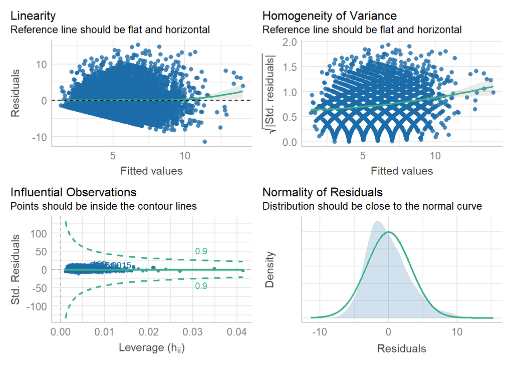

```r
performance::check_model(mixedmodel.wt,check=c('normality','linearity','homogeneity','outliers'))
```

### Generate Table 3 of results of weighted LMM.

Display fixed effects and variations of random effects in weighted LMM.

```r
tab_model(mixedmodel.wt,show.ci = 0.95,show.p = TRUE,show.re.var = TRUE,show.ngroups = FALSE,
          show.aic = FALSE,show.r2=FALSE,digits = 3,digits.re = 3)
```

|  | zPSQI |  |  |
| --- | --- | --- | --- |
| Predictors | Estimates | CI | p |
| (Intercept) | 3.605 | 0.690 – 6.520 | **0.015** |
| gender [Male] | -0.093 | -0.251 – 0.064 | 0.245 |
| age | 0.142 | 0.054 – 0.231 | **0.002** |
| BMI | -0.011 | -0.029 – 0.007 | 0.231 |
| NativePlace [Urban] | -0.072 | -0.230 – 0.086 | 0.370 |
| OnlyChild [Yes] | -0.083 | -0.233 – 0.067 | 0.277 |
| FatherEducationLevel | -0.101 | -0.224 – 0.023 | 0.111 |
| MotherEducationLevel | 0.065 | -0.069 – 0.200 | 0.340 |
| FamilyEconomicLevel | 0.018 | -0.147 – 0.183 | 0.833 |
| MonthlyLivingExpense | -0.066 | -0.213 – 0.080 | 0.375 |
| PhysicalExercise | -0.096 | -0.218 – 0.027 | 0.126 |
| RoommateSleepsLate [Yes] | 0.303 | 0.148 – 0.459 | **<0.001** |
| NoisyDormitory [Yes] | 0.582 | 0.394 – 0.770 | **<0.001** |
| DormitoryLight [Bright] | -0.031 | -0.189 – 0.126 | 0.697 |
| DormitoryHygiene [Poor] | -0.101 | -0.253 – 0.050 | 0.190 |
| RelationshipWithClassmates | 0.557 | -0.361 – 1.475 | 0.234 |
| AmativenessMatter [Ever] | 0.027 | -0.127 – 0.181 | 0.732 |
| AmativenessMatter [BeingInlove] | 0.052 | -0.132 – 0.236 | 0.578 |
| MedicalMajor [Yes] | -0.179 | -0.376 – 0.019 | 0.077 |
| zCDRISC | -0.016 | -0.019 – -0.012 | **<0.001** |
| zMPAI | 0.043 | 0.038 – 0.049 | **<0.001** |
| Random Effects |  |  |  |
| σ<sup>2</sup> | 16.687 |  |  |
| τ<sub>00</sub> <sub>grade.ord</sub> | 0.047 |  |  |
| τ<sub>00</sub> <sub>EmploymentPressure.ord</sub> | 0.127 |  |  |
| τ<sub>00</sub> <sub>AcademicPressure.ord</sub> | 1.176 |  |  |
| τ<sub>00</sub> <sub>MentalHealthStatus.ord</sub> | 0.802 |  |  |
| τ<sub>00</sub> <sub>PhysicalHealthStatus.ord</sub> | 0.636 |  |  |
| τ<sub>00</sub> <sub>ReceivedPsychologicalCounseling</sub> | 0.195 |  |  |
| τ<sub>00</sub> <sub>drinking</sub> | 0.081 |  |  |
| τ<sub>00</sub> <sub>smoking</sub> | 0.332 |  |  |
| τ<sub>11</sub> <sub>EmploymentPressure.ord.RelationshipWithClassmates</sub> | 0.063 |  |  |
| τ<sub>11</sub> <sub>AcademicPressure.ord.RelationshipWithClassmates</sub> | 0.545 |  |  |
| ρ<sub>01</sub> <sub>EmploymentPressure.ord</sub> | -0.842 |  |  |
| ρ<sub>01</sub> <sub>AcademicPressure.ord</sub> | -0.982 |  |  |
| ICC | 0.123 |  |  |
| Observations | 8457 |  |  |

Linear trend test for continuous variables in weighted LMM.

```r
mydata <- mydata %>% mutate(
  age.ord = factor(cut(age,breaks = 4,labels=c(1,2,3,4)),ordered = T),
  BMI.ord = factor(cut(BMI,breaks = 4,labels=c(1,2,3,4)),ordered = T),
  zCDRISC.ord = factor(cut(zCDRISC,breaks = 4,labels=c(1,2,3,4)),ordered = T),
  zMPAI.ord = factor(cut(zMPAI,breaks = 4,labels=c(1,2,3,4)),ordered = T),
)
summary(update(mixedmodel.wt, .~. - age + age.ord))$coefficients[c('age.ord.L','age.ord.Q'),]
```

```
##           Estimate Std. Error   df t value Pr(>|t|)
## age.ord.L   0.2557     0.1357 1848   1.884  0.05971
## age.ord.Q   0.2511     0.1021 4322   2.459  0.01396
```

```r
summary(update(mixedmodel.wt, .~. - zCDRISC + zCDRISC.ord))$coefficients[c('zCDRISC.ord.L','zCDRISC.ord.Q'),]
```

```
##               Estimate Std. Error   df t value  Pr(>|t|)
## zCDRISC.ord.L  -0.6195     0.1543 8424  -4.016 5.978e-05
## zCDRISC.ord.Q  -0.1951     0.1254 8410  -1.555 1.199e-01
```

```r
summary(update(mixedmodel.wt, .~. - zMPAI + zMPAI.ord))$coefficients[c('zMPAI.ord.L','zMPAI.ord.Q'),]
```

```
##             Estimate Std. Error   df t value  Pr(>|t|)
## zMPAI.ord.L  1.45990     0.1507 8424  9.6865 4.483e-22
## zMPAI.ord.Q -0.04025     0.1186 8401 -0.3393 7.344e-01
```

### Plot Figure S7.

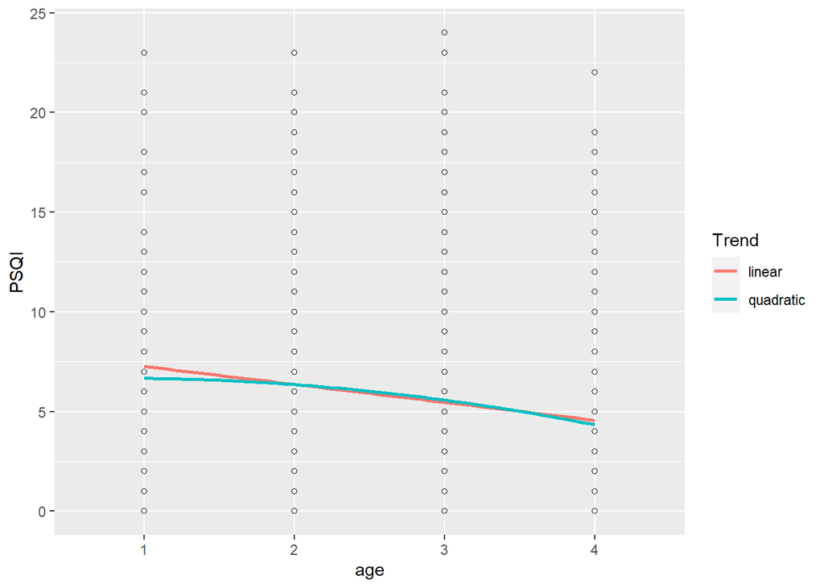

```r
ggplot(mydata) +
  aes(x = zCDRISC.ord, y = zPSQI) +
  geom_point(shape = 1) +
  geom_smooth(aes(x = unclass(zCDRISC.ord), color = "1"),
              formula = y ~ x,
              method = lm, se = FALSE) +
  geom_smooth(aes(x = unclass(zCDRISC.ord), color = "2"),
              formula = y ~ poly(x, 2),
              method = lm, se = FALSE) +
  scale_color_discrete("Trend", labels = c("linear", "quadratic")) +
  labs(x = 'age',y = 'PSQI')
```

### Plot Figure 2.

Display random effects of weighted LMM.

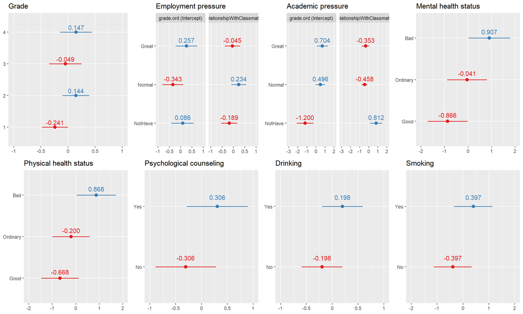

```r
namelist <- list('Grade','Employment pressure',
               'Academic pressure','Mental health status',
               'Physical health status',
               'Psychological counseling',
               'Drinking','Smoking')
fig.list <- list()
for (i in 1:length(ranef(mixedmodel.wt))) {
fig.list[[i]] <-
  plot_model(mixedmodel.wt,
             type = "re"
             ,ri.nr = i
             ,title = namelist[[i]]
             ,show.values=T
             ,digits = 3
             ,auto.label=T)
}

cowplot::plot_grid(fig.list[[1]],fig.list[[2]],fig.list[[3]],fig.list[[4]],
          fig.list[[5]],fig.list[[6]],fig.list[[7]],fig.list[[8]],ncol=4)
```

```r
# plot_model(mixedmodel.wt, type = "eff", terms = "zMPAI")
```

### Logistic regression with random effects (LRRE)

```r
gmixed.formula.full <- update(mixed.reg.formula, zPSQI.cat ~ .)
gmixedmodel.full <- glmer(data = mydata
                          ,formula = gmixed.formula.full
                          ,family = 'binomial')
```

Perform likelihood ratio test to check significance of random effects in LRRE.

```r
gmixedmodel.grade <- update(gmixedmodel.full, . ~ . - (1 |grade.ord))
anova(gmixedmodel.full,gmixedmodel.grade)
```

```
## Data: mydata
## Models:
## gmixedmodel.grade: zPSQI.cat ~ gender + age + BMI + NativePlace + OnlyChild + FatherEducationLevel + MotherEducationLevel + FamilyEconomicLevel + MonthlyLivingExpense + PhysicalExercise + RoommateSleepsLate + NoisyDormitory + DormitoryLight + DormitoryHygiene + RelationshipWithClassmates + Amativ…
## gmixedmodel.full: zPSQI.cat ~ gender + age + BMI + NativePlace + OnlyChild + FatherEducationLevel + MotherEducationLevel + FamilyEconomicLevel + MonthlyLivingExpense + PhysicalExercise + RoommateSleepsLate + NoisyDormitory + DormitoryLight + DormitoryHygiene + RelationshipWithClassmates + Amative…
##                   npar  AIC  BIC logLik deviance Chisq Df Pr(>Chisq)
## gmixedmodel.grade   32 8894 9119  -4415     8830
## gmixedmodel.full    33 8887 9119  -4410     8821   9.1  1     0.0026 **
## ---
## Signif. codes:  0 '***' 0.001 '**' 0.01 '*' 0.05 '.' 0.1 ' ' 1
```

```r
gmixedmodel.smoke <- update(gmixedmodel.full, . ~ . - (1 |smoking))
anova(gmixedmodel.full,gmixedmodel.smoke)
```

```
## Data: mydata
## Models:
## gmixedmodel.smoke: zPSQI.cat ~ gender + age + BMI + NativePlace + OnlyChild + FatherEducationLevel + MotherEducationLevel + FamilyEconomicLevel + MonthlyLivingExpense + PhysicalExercise + RoommateSleepsLate + NoisyDormitory + DormitoryLight + DormitoryHygiene + RelationshipWithClassmates + Amativ…
## gmixedmodel.full: zPSQI.cat ~ gender + age + BMI + NativePlace + OnlyChild + FatherEducationLevel + MotherEducationLevel + FamilyEconomicLevel + MonthlyLivingExpense + PhysicalExercise + RoommateSleepsLate + NoisyDormitory + DormitoryLight + DormitoryHygiene + RelationshipWithClassmates + Amative…
##                   npar  AIC  BIC logLik deviance Chisq Df Pr(>Chisq)
## gmixedmodel.smoke   32 8897 9122  -4416     8833
## gmixedmodel.full    33 8887 9119  -4410     8821  12.1  1      5e-04 ***
## ---
## Signif. codes:  0 '***' 0.001 '**' 0.01 '*' 0.05 '.' 0.1 ' ' 1
```

```r
gmixedmodel.drink <- update(gmixedmodel.full, . ~ . - (1 |drinking))
anova(gmixedmodel.full,gmixedmodel.drink)
```

```
## Data: mydata
## Models:
## gmixedmodel.drink: zPSQI.cat ~ gender + age + BMI + NativePlace + OnlyChild + FatherEducationLevel + MotherEducationLevel + FamilyEconomicLevel + MonthlyLivingExpense + PhysicalExercise + RoommateSleepsLate + NoisyDormitory + DormitoryLight + DormitoryHygiene + RelationshipWithClassmates + Amativ…
## gmixedmodel.full: zPSQI.cat ~ gender + age + BMI + NativePlace + OnlyChild + FatherEducationLevel + MotherEducationLevel + FamilyEconomicLevel + MonthlyLivingExpense + PhysicalExercise + RoommateSleepsLate + NoisyDormitory + DormitoryLight + DormitoryHygiene + RelationshipWithClassmates + Amative…
##                   npar  AIC  BIC logLik deviance Chisq Df Pr(>Chisq)
## gmixedmodel.drink   32 8891 9117  -4414     8827
## gmixedmodel.full    33 8887 9119  -4410     8821  6.76  1     0.0093 **
## ---
## Signif. codes:  0 '***' 0.001 '**' 0.01 '*' 0.05 '.' 0.1 ' ' 1
```

```r
gmixedmodel.phs <- update(gmixedmodel.full, . ~ . - (1 |PhysicalHealthStatus.ord))
anova(gmixedmodel.full,gmixedmodel.phs)
```

```
## Data: mydata
## Models:
## gmixedmodel.phs: zPSQI.cat ~ gender + age + BMI + NativePlace + OnlyChild + FatherEducationLevel + MotherEducationLevel + FamilyEconomicLevel + MonthlyLivingExpense + PhysicalExercise + RoommateSleepsLate + NoisyDormitory + DormitoryLight + DormitoryHygiene + RelationshipWithClassmates + Amativen…
## gmixedmodel.full: zPSQI.cat ~ gender + age + BMI + NativePlace + OnlyChild + FatherEducationLevel + MotherEducationLevel + FamilyEconomicLevel + MonthlyLivingExpense + PhysicalExercise + RoommateSleepsLate + NoisyDormitory + DormitoryLight + DormitoryHygiene + RelationshipWithClassmates + Amative…
##                  npar  AIC  BIC logLik deviance Chisq Df Pr(>Chisq)
## gmixedmodel.phs    32 8898 9123  -4417     8834
## gmixedmodel.full   33 8887 9119  -4410     8821  13.2  1    0.00029 ***
## ---
## Signif. codes:  0 '***' 0.001 '**' 0.01 '*' 0.05 '.' 0.1 ' ' 1
```

```r
gmixedmodel.mhs <- update(gmixedmodel.full, . ~ . - (1 |MentalHealthStatus.ord))
anova(gmixedmodel.full,gmixedmodel.mhs)
```

```
## Data: mydata
## Models:
## gmixedmodel.mhs: zPSQI.cat ~ gender + age + BMI + NativePlace + OnlyChild + FatherEducationLevel + MotherEducationLevel + FamilyEconomicLevel + MonthlyLivingExpense + PhysicalExercise + RoommateSleepsLate + NoisyDormitory + DormitoryLight + DormitoryHygiene + RelationshipWithClassmates + Amativen…
## gmixedmodel.full: zPSQI.cat ~ gender + age + BMI + NativePlace + OnlyChild + FatherEducationLevel + MotherEducationLevel + FamilyEconomicLevel + MonthlyLivingExpense + PhysicalExercise + RoommateSleepsLate + NoisyDormitory + DormitoryLight + DormitoryHygiene + RelationshipWithClassmates + Amative…
##                  npar  AIC  BIC logLik deviance Chisq Df Pr(>Chisq)
## gmixedmodel.mhs    32 8957 9182  -4446     8893
## gmixedmodel.full   33 8887 9119  -4410     8821  72.1  1     <2e-16 ***
## ---
## Signif. codes:  0 '***' 0.001 '**' 0.01 '*' 0.05 '.' 0.1 ' ' 1
```

```r
gmixedmodel.rpc <- update(gmixedmodel.full, . ~ . - (1 |ReceivedPsychologicalCounseling))
anova(gmixedmodel.full,gmixedmodel.rpc)
```

```
## Data: mydata
## Models:
## gmixedmodel.rpc: zPSQI.cat ~ gender + age + BMI + NativePlace + OnlyChild + FatherEducationLevel + MotherEducationLevel + FamilyEconomicLevel + MonthlyLivingExpense + PhysicalExercise + RoommateSleepsLate + NoisyDormitory + DormitoryLight + DormitoryHygiene + RelationshipWithClassmates + Amativen…
## gmixedmodel.full: zPSQI.cat ~ gender + age + BMI + NativePlace + OnlyChild + FatherEducationLevel + MotherEducationLevel + FamilyEconomicLevel + MonthlyLivingExpense + PhysicalExercise + RoommateSleepsLate + NoisyDormitory + DormitoryLight + DormitoryHygiene + RelationshipWithClassmates + Amative…
##                  npar  AIC  BIC logLik deviance Chisq Df Pr(>Chisq)
## gmixedmodel.rpc    32 8896 9122  -4416     8832
## gmixedmodel.full   33 8887 9119  -4410     8821  11.8  1      6e-04 ***
## ---
## Signif. codes:  0 '***' 0.001 '**' 0.01 '*' 0.05 '.' 0.1 ' ' 1
```

```r
gmixedmodel.rwc <- update(gmixedmodel.full, . ~ .
                          - (1 + RelationshipWithClassmates|AcademicPressure.ord)
                          + (1 | AcademicPressure.ord))
anova(gmixedmodel.full,gmixedmodel.rwc)
```

```
## Data: mydata
## Models:
## gmixedmodel.rwc: zPSQI.cat ~ gender + age + BMI + NativePlace + OnlyChild + FatherEducationLevel + MotherEducationLevel + FamilyEconomicLevel + MonthlyLivingExpense + PhysicalExercise + RoommateSleepsLate + NoisyDormitory + DormitoryLight + DormitoryHygiene + RelationshipWithClassmates + Amativen…
## gmixedmodel.full: zPSQI.cat ~ gender + age + BMI + NativePlace + OnlyChild + FatherEducationLevel + MotherEducationLevel + FamilyEconomicLevel + MonthlyLivingExpense + PhysicalExercise + RoommateSleepsLate + NoisyDormitory + DormitoryLight + DormitoryHygiene + RelationshipWithClassmates + Amative…
##                  npar  AIC  BIC logLik deviance Chisq Df Pr(>Chisq)
## gmixedmodel.rwc    31 8885 9104  -4412     8823
## gmixedmodel.full   33 8887 9119  -4410     8821  2.78  2       0.25
```

```r
gmixedmodel.ap <- update(gmixedmodel.rwc, . ~ . - (1 | AcademicPressure.ord))
anova(gmixedmodel.full,gmixedmodel.ap)
```

```
## Data: mydata
## Models:
## gmixedmodel.ap: zPSQI.cat ~ gender + age + BMI + NativePlace + OnlyChild + FatherEducationLevel + MotherEducationLevel + FamilyEconomicLevel + MonthlyLivingExpense + PhysicalExercise + RoommateSleepsLate + NoisyDormitory + DormitoryLight + DormitoryHygiene + RelationshipWithClassmates + Amativene…
## gmixedmodel.full: zPSQI.cat ~ gender + age + BMI + NativePlace + OnlyChild + FatherEducationLevel + MotherEducationLevel + FamilyEconomicLevel + MonthlyLivingExpense + PhysicalExercise + RoommateSleepsLate + NoisyDormitory + DormitoryLight + DormitoryHygiene + RelationshipWithClassmates + Amative…
##                  npar  AIC  BIC logLik deviance Chisq Df Pr(>Chisq)
## gmixedmodel.ap     30 8889 9100  -4414     8829
## gmixedmodel.full   33 8887 9119  -4410     8821  7.96  3      0.047 *
## ---
## Signif. codes:  0 '***' 0.001 '**' 0.01 '*' 0.05 '.' 0.1 ' ' 1
```

```r
gmixedmodel.rwcep <- update(gmixedmodel.full, . ~ .
                            - (1 + RelationshipWithClassmates|EmploymentPressure.ord)
                            + (1 | EmploymentPressure.ord))
anova(gmixedmodel.full,gmixedmodel.rwcep)
```

```
## Data: mydata
## Models:
## gmixedmodel.rwcep: zPSQI.cat ~ gender + age + BMI + NativePlace + OnlyChild + FatherEducationLevel + MotherEducationLevel + FamilyEconomicLevel + MonthlyLivingExpense + PhysicalExercise + RoommateSleepsLate + NoisyDormitory + DormitoryLight + DormitoryHygiene + RelationshipWithClassmates + Amativ…
## gmixedmodel.full: zPSQI.cat ~ gender + age + BMI + NativePlace + OnlyChild + FatherEducationLevel + MotherEducationLevel + FamilyEconomicLevel + MonthlyLivingExpense + PhysicalExercise + RoommateSleepsLate + NoisyDormitory + DormitoryLight + DormitoryHygiene + RelationshipWithClassmates + Amative…
##                   npar  AIC  BIC logLik deviance Chisq Df Pr(>Chisq)
## gmixedmodel.rwcep   31 8887 9105  -4412     8825
## gmixedmodel.full    33 8887 9119  -4410     8821  4.11  2       0.13
```

```r
gmixedmodel.ep <- update(gmixedmodel.rwcep, . ~ . - (1 | EmploymentPressure.ord))
anova(gmixedmodel.full,gmixedmodel.ep)
```

```
## Data: mydata
## Models:
## gmixedmodel.ep: zPSQI.cat ~ gender + age + BMI + NativePlace + OnlyChild + FatherEducationLevel + MotherEducationLevel + FamilyEconomicLevel + MonthlyLivingExpense + PhysicalExercise + RoommateSleepsLate + NoisyDormitory + DormitoryLight + DormitoryHygiene + RelationshipWithClassmates + Amativene…
## gmixedmodel.full: zPSQI.cat ~ gender + age + BMI + NativePlace + OnlyChild + FatherEducationLevel + MotherEducationLevel + FamilyEconomicLevel + MonthlyLivingExpense + PhysicalExercise + RoommateSleepsLate + NoisyDormitory + DormitoryLight + DormitoryHygiene + RelationshipWithClassmates + Amative…
##                  npar  AIC  BIC logLik deviance Chisq Df Pr(>Chisq)
## gmixedmodel.ep     30 8893 9104  -4416     8833
## gmixedmodel.full   33 8887 9119  -4410     8821  12.1  3     0.0071 **
## ---
## Signif. codes:  0 '***' 0.001 '**' 0.01 '*' 0.05 '.' 0.1 ' ' 1
```

```r
performance::check_collinearity(gmixedmodel.full)
```

```
## # Check for Multicollinearity
##
## Low Correlation
##
##                        Term  VIF   VIF 95% CI Increased SE Tolerance
##                      gender 1.11 [1.08, 1.14]         1.05      0.90
##                         age 1.03 [1.02, 1.06]         1.02      0.97
##                         BMI 1.03 [1.02, 1.07]         1.02      0.97
##                 NativePlace 1.36 [1.32, 1.39]         1.16      0.74
##                   OnlyChild 1.21 [1.19, 1.25]         1.10      0.82
##        FatherEducationLevel 1.93 [1.87, 2.00]         1.39      0.52
##        MotherEducationLevel 1.94 [1.88, 2.00]         1.39      0.52
##         FamilyEconomicLevel 1.25 [1.22, 1.28]         1.12      0.80
##        MonthlyLivingExpense 1.27 [1.24, 1.30]         1.13      0.79
##            PhysicalExercise 1.04 [1.02, 1.07]         1.02      0.96
##          RoommateSleepsLate 1.29 [1.26, 1.33]         1.14      0.77
##              NoisyDormitory 1.38 [1.34, 1.42]         1.17      0.73
##              DormitoryLight 1.15 [1.13, 1.18]         1.07      0.87
##            DormitoryHygiene 1.05 [1.03, 1.08]         1.03      0.95
##  RelationshipWithClassmates 1.00 [1.00, 1.78]         1.00      1.00
##           AmativenessMatter 1.03 [1.01, 1.06]         1.01      0.97
##                MedicalMajor 1.01 [1.00, 1.08]         1.01      0.99
##                     zCDRISC 1.03 [1.02, 1.06]         1.02      0.97
##                       zMPAI 1.04 [1.02, 1.07]         1.02      0.96
##  Tolerance 95% CI
##      [0.88, 0.92]
##      [0.94, 0.98]
##      [0.94, 0.98]
##      [0.72, 0.76]
##      [0.80, 0.84]
##      [0.50, 0.53]
##      [0.50, 0.53]
##      [0.78, 0.82]
##      [0.77, 0.81]
##      [0.94, 0.98]
##      [0.75, 0.79]
##      [0.71, 0.75]
##      [0.84, 0.89]
##      [0.92, 0.97]
##      [0.56, 1.00]
##      [0.94, 0.99]
##      [0.93, 1.00]
##      [0.94, 0.98]
##      [0.93, 0.98]
```

```r
performance::check_outliers(gmixedmodel.full)
```

```
## OK: No outliers detected.
## - Based on the following method and threshold: cook (0.934).
## - For variable: (Whole model)
```

```r
performance::check_overdispersion(gmixedmodel.full)
```

```
## # Overdispersion test
##
##        dispersion ratio =    0.986
##   Pearson's Chi-Squared = 8303.744
##                 p-value =    0.823
```

```
## No overdispersion detected.
```

```r
performance::check_autocorrelation(gmixedmodel.full)
```

```
## OK: Residuals appear to be independent and not autocorrelated (p = 0.088).
```

```r
performance::model_performance(gmixedmodel.full)
```

```
## # Indices of model performance
##
## AIC      |     AICc |      BIC | R2 (cond.) | R2 (marg.) |   ICC |  RMSE | Sigma | Log_loss | Score_log | Score_spherical
## -------------------------------------------------------------------------------------------------------------------------
## 8886.648 | 8886.915 | 9119.059 |      0.189 |      0.068 | 0.130 | 0.414 | 1.000 |    0.518 |      -Inf |       1.264e-04
```

```r
mydata <- mydata %>% mutate(
  prob = predict(gmixedmodel.full,type = 'response'),
  logitP = log(prob/(1-prob))
)

gmixed.linear.formula <- update(gmixed.formula.full, logitP ~ .)
gmixed.linear <- gmixedmodel.linear <- lmer(
  data = mydata
  ,formula = gmixed.linear.formula)
```

### Plot Figure S4.

Performance of linearity after diagnostics of LRRE.

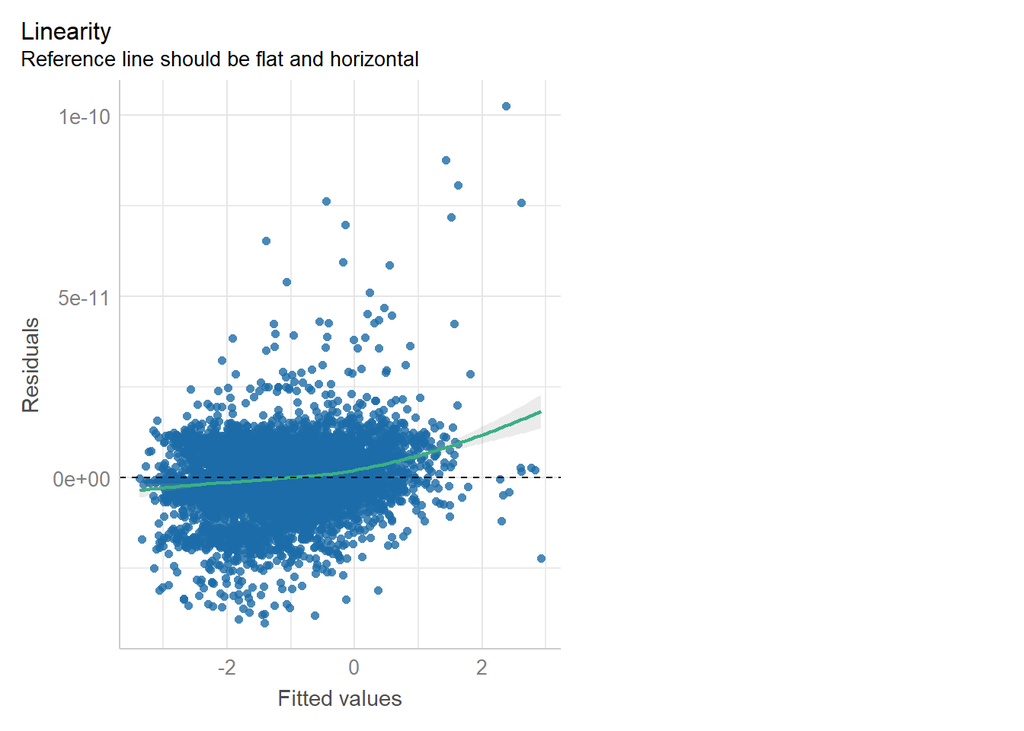

```r
performance::check_model(gmixed.linear,check=c('linearity'))
```

Display fixed effects and variations of random effects in LRRE.

```r
tab_model(gmixedmodel.full,show.ci = 0.95,show.p = TRUE,show.re.var = TRUE,show.ngroups = FALSE,
          show.aic = FALSE,show.r2=FALSE,digits = 3,digits.re = 3)
```

|  | zPSQI.cat |  |  |
| --- | --- | --- | --- |
| Predictors | Odds Ratios | CI | p |
| (Intercept) | 0.155 | 0.025 – 0.955 | **0.044** |
| gender [Male] | 0.994 | 0.877 – 1.126 | 0.921 |
| age | 1.071 | 0.999 – 1.148 | 0.053 |
| BMI | 0.983 | 0.969 – 0.998 | **0.022** |
| NativePlace [Urban] | 0.957 | 0.845 – 1.084 | 0.490 |
| OnlyChild [Yes] | 0.880 | 0.782 – 0.990 | **0.034** |
| FatherEducationLevel | 0.886 | 0.801 – 0.979 | **0.017** |
| MotherEducationLevel | 1.159 | 1.041 – 1.290 | **0.007** |
| FamilyEconomicLevel | 1.040 | 0.916 – 1.180 | 0.545 |
| MonthlyLivingExpense | 0.917 | 0.819 – 1.027 | 0.133 |
| PhysicalExercise | 0.981 | 0.893 – 1.078 | 0.688 |
| RoommateSleepsLate [Yes] | 1.149 | 1.020 – 1.294 | **0.022** |
| NoisyDormitory [Yes] | 1.405 | 1.229 – 1.606 | **<0.001** |
| DormitoryLight [Bright] | 0.986 | 0.873 – 1.114 | 0.823 |
| DormitoryHygiene [Poor] | 0.911 | 0.813 – 1.021 | 0.110 |
| RelationshipWithClassmates | 1.229 | 0.736 – 2.053 | 0.431 |
| AmativenessMatter [Ever] | 1.039 | 0.921 – 1.172 | 0.537 |
| AmativenessMatter [BeingInlove] | 1.131 | 0.981 – 1.304 | 0.091 |
| MedicalMajor [Yes] | 0.946 | 0.807 – 1.109 | 0.495 |
| zCDRISC | 0.992 | 0.988 – 0.995 | **<0.001** |
| zMPAI | 1.024 | 1.020 – 1.028 | **<0.001** |
| Random Effects |  |  |  |
| σ<sup>2</sup> | 3.290 |  |  |
| τ<sub>00</sub> <sub>grade.ord</sub> | 0.015 |  |  |
| τ<sub>00</sub> <sub>EmploymentPressure.ord</sub> | 0.086 |  |  |
| τ<sub>00</sub> <sub>AcademicPressure.ord</sub> | 0.182 |  |  |
| τ<sub>00</sub> <sub>MentalHealthStatus.ord</sub> | 0.182 |  |  |
| τ<sub>00</sub> <sub>PhysicalHealthStatus.ord</sub> | 0.080 |  |  |
| τ<sub>00</sub> <sub>ReceivedPsychologicalCounseling</sub> | 0.041 |  |  |
| τ<sub>00</sub> <sub>drinking</sub> | 0.016 |  |  |
| τ<sub>00</sub> <sub>smoking</sub> | 0.084 |  |  |
| τ<sub>11</sub> <sub>EmploymentPressure.ord.RelationshipWithClassmates</sub> | 0.040 |  |  |
| τ<sub>11</sub> <sub>AcademicPressure.ord.RelationshipWithClassmates</sub> | 0.130 |  |  |
| ρ<sub>01</sub> <sub>EmploymentPressure.ord</sub> | -0.875 |  |  |
| ρ<sub>01</sub> <sub>AcademicPressure.ord</sub> | -0.978 |  |  |
| ICC | 0.130 |  |  |
| Observations | 8457 |  |  |

### Plot Figure 3.

Display ORs of random effects of LRRE.

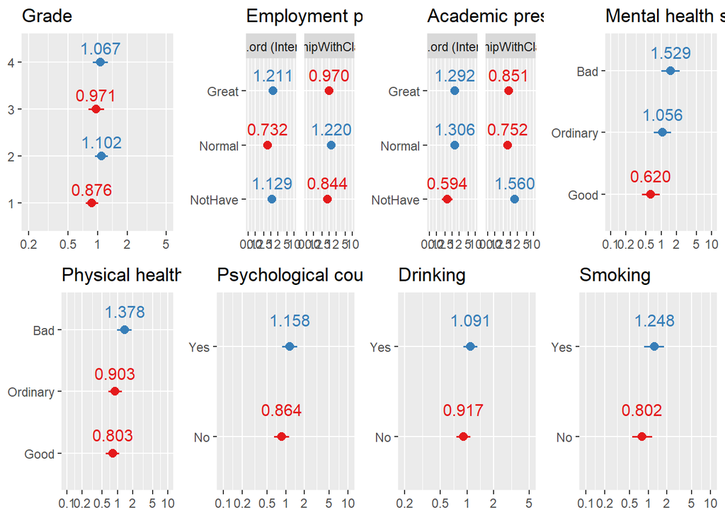

```r
fig.list <- list()
for (i in 1:length(ranef(gmixedmodel.full))) {
  fig.list[[i]] <-
    plot_model(gmixedmodel.full,
               type = "re"
               ,ri.nr = i
               ,title = namelist[[i]]
               ,value.offset = .3
               ,show.values=T
               ,digits = 3
               ,auto.label=T)
}
cowplot::plot_grid(fig.list[[1]],fig.list[[2]],fig.list[[3]],fig.list[[4]],
          fig.list[[5]],fig.list[[6]],fig.list[[7]],fig.list[[8]],ncol=4)
```

### Plot Figure S8.

Display ROC of LRRE.

```r
predict_<-predict(gmixedmodel.full,type='response')
modelroc <- roc(mydata$zPSQI.cat,predict_)
```

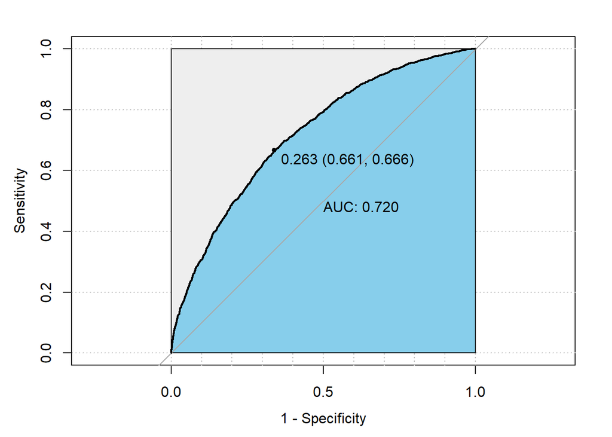

```r
plot(modelroc
     ,print.auc=TRUE
     ,auc.polygon=TRUE
     ,legacy.axes=TRUE
     ,grid=c(0.1, 0.2)
     ,grid.col=c("grey", "grey")
     ,max.auc.polygon=TRUE
     ,auc.polygon.col="skyblue"
     ,print.thres=TRUE
)
```

Linear trend test for continuous variables in LRRE.

```r
summary(update(gmixedmodel.full, .~. - BMI + BMI.ord))$coefficients[c('BMI.ord.L','BMI.ord.Q'),]
```

```
##           Estimate Std. Error z value Pr(>|z|)
## BMI.ord.L  -0.7395     0.2887  -2.561  0.01042
## BMI.ord.Q   0.2839     0.2184   1.300  0.19361
```

```r
summary(update(gmixedmodel.full, .~. - zCDRISC + zCDRISC.ord))$coefficients[c('zCDRISC.ord.L','zCDRISC.ord.Q'),]
```

```
##               Estimate Std. Error z value  Pr(>|z|)
## zCDRISC.ord.L -0.39630    0.11919 -3.3248 0.0008848
## zCDRISC.ord.Q -0.06089    0.09449 -0.6444 0.5193351
```

```r
summary(update(gmixedmodel.full, .~. - zMPAI + zMPAI.ord))$coefficients[c('zMPAI.ord.L','zMPAI.ord.Q'),]
```

```
##             Estimate Std. Error z value  Pr(>|z|)
## zMPAI.ord.L  0.77478    0.09429  8.2169 2.088e-16
## zMPAI.ord.Q -0.06651    0.07505 -0.8862 3.755e-01
```

```r
summary(update(gmixedmodel.full, .~. - FatherEducationLevel + FatherEducationLevel.ord))$coefficients[c('FatherEducationLevel.ord.L','FatherEducationLevel.ord.Q'),]
```

```
##                            Estimate Std. Error z value Pr(>|z|)
## FatherEducationLevel.ord.L -0.15757    0.07400 -2.1292  0.03324
## FatherEducationLevel.ord.Q  0.05186    0.06413  0.8087  0.41871
```

```r
summary(update(gmixedmodel.full, .~. - MotherEducationLevel + MotherEducationLevel.ord))$coefficients[c('MotherEducationLevel.ord.L','MotherEducationLevel.ord.Q'),]
```

```
##                            Estimate Std. Error z value Pr(>|z|)
## MotherEducationLevel.ord.L  0.21216    0.07928  2.6760 0.007451
## MotherEducationLevel.ord.Q  0.01256    0.06768  0.1856 0.852788
```